# Analysis using 3 datasets

#### 8c. Backgrounds, outcomes, matching quality, and forrest plot among those **Surgery care unit** at treatment start.

```r
FORMULA_ovl2_surg <- drug01 ~  age_cat + sex + sirs + pre_blood_culture + treat_van + vasopressor + base_crea + near_crea +  base_KDIGO

#1. overlap-PSM using MIMIC3, "Young"
OVLP(comb_DF2ovl %>% subset(dataset=="MIMIC3"&dep_type2=="Surgery"), FORMULA_ovl2_surg, "Ovlp_MIMIC3_surg", "**Ovlp, MIMIC-III, Surgical unit**")
```

| **Characteristic** | **Ovlp, MIMIC-III, Surgical unit** **I/C** N=22.8<sup>1</sup> | **Ovlp, MIMIC-III, Surgical unit** **NCC** N=22.8<sup>1</sup> | **p-value**<sup>2</sup> |  |
| --- | --- | --- | --- | --- |
| dataset |  |  |  |  |
| MIMIC3 | 22.8 (100.0%) | 22.8 (100.0%) |  |  |
| age_group |  |  | 0.063 |  |
| 18-39 | 0.0 (0.0%) | 1.2 (5.4%) |  |  |
| 40-49 | 4.9 (21.5%) | 1.8 (7.9%) |  |  |
| 50-59 | 2.8 (12.0%) | 2.6 (11.4%) |  |  |
| 60-69 | 4.4 (19.2%) | 5.8 (25.4%) |  |  |
| 70-79 | 4.7 (20.7%) | 8.0 (34.9%) |  |  |
| 80+ | 6.1 (26.6%) | 3.4 (14.9%) |  |  |
| sex |  |  | >0.99 |  |
| Female | 8.9 (39.0%) | 8.9 (39.0%) |  |  |
| Male | 13.9 (61.0%) | 13.9 (61.0%) |  |  |
| bmi | 28.0 (24.7, 36.1) | 27.5 (23.4, 33.9) | 0.32 |  |
| Unknown | 9 | 7 |  |  |
| ICU type |  |  |  |  |
| Surgery | 22.8 (100.0%) | 22.8 (100.0%) |  |  |
| drug_name |  |  |  |  |
| Imipenem/cilastatin | 22.8 (100.0%) | 0.0 (0.0%) |  |  |
| Imipenem/cilastatin/relebactam | 0.0 (0.0%) | 0.0 (0.0%) |  |  |
| Meropenem | 0.0 (0.0%) | 22.8 (100.0%) |  |  |
| Doripenem | 0.0 (0.0%) | 0.0 (0.0%) |  |  |
| Ertapenem | 0.0 (0.0%) | 0.0 (0.0%) |  |  |
| sofa | 5.0 (3.0, 9.0) | 3.0 (2.0, 6.0) | 0.061 |  |
| qsofa | 1.0 (0.0, 1.0) | 1.0 (0.0, 1.0) | 0.58 |  |
| Unknown | 0 | 0 |  |  |
| sirs | 2.0 (1.0, 3.0) | 2.0 (1.0, 3.0) | 0.89 |  |
| pre_blood_culture | 17.2 (75.4%) | 17.2 (75.4%) | >0.99 |  |
| pre vancomycin use | 6.3 (27.5%) | 6.3 (27.5%) | >0.99 |  |
| pre vasopressor use | 9.7 (42.6%) | 9.7 (42.6%) | >0.99 |  |
| pre ventilation | 17.1 (75.0%) | 16.5 (72.5%) | 0.78 |  |
| Baseline sCr | 0.9 (0.5, 1.3) | 0.8 (0.6, 1.3) | 0.72 |  |
| sCr at treatment start | 1.2 (0.7, 1.4) | 1.0 (0.7, 1.4) | 0.50 |  |
| AKI stage at treatment start |  |  | 0.12 |  |
| 0 | 20.4 (89.5%) | 19.6 (85.6%) |  |  |
| 1 | 1.5 (6.5%) | 3.3 (14.3%) |  |  |
| 2 | 0.9 (4.0%) | 0.0 (0.1%) |  |  |
| observation time | 168.0 (168.0, 168.0) | 168.0 (168.0, 168.0) | 0.80 |  |
| Cencsored with drug change | 0.8 (3.5%) | 0.2 (0.7%) | 0.22 |  |
| RRT at treatment start | 0.0 (0.0%) | 0.0 (0.0%) |  |  |
| O, AKI develop/progress | 6.6 (29.0%) | 8.0 (35.2%) | 0.54 |  |
| O, Death | 2.0 (8.7%) | 2.4 (10.7%) | 0.75 |  |
| O, AKI d/p or death | 6.6 (29.0%) | 9.5 (41.7%) | 0.22 |  |
| O, RRT-intervention | 0.7 (3.0%) | 0.3 (1.4%) | 0.52 |  |
| O, Death or RRT-intervention | 2.0 (8.7%) | 2.8 (12.1%) | 0.61 |  |

<sup>1</sup> n (%); Median (Q1, Q3)  
<sup>2</sup> NA; Pearson’s X^2: Rao & Scott adjustment; Design-based KruskalWallis test

```r
#2. overlap-PSM using MIMIC4, "Young"
OVLP(comb_DF2ovl %>% subset(dataset=="miiv"&dep_type2=="Surgery"), FORMULA_ovl2_surg, "Ovlp_MIMIC4_surg", "**Ovlp, MIMIC-IV, Surgical unit**")
```

| **Characteristic** | **Ovlp, MIMIC-IV, Surgical unit** **I/C** N=14.3<sup>1</sup> | **Ovlp, MIMIC-IV, Surgical unit** **NCC** N=14.3<sup>1</sup> | **p-value**<sup>2</sup> |  |
| --- | --- | --- | --- | --- |
| dataset |  |  |  |  |
| miiv | 14.3 (100.0%) | 14.3 (100.0%) |  |  |
| age_group |  |  | 0.66 |  |
| 18-39 | 2.0 (13.6%) | 2.2 (15.4%) |  |  |
| 40-49 | 2.8 (19.5%) | 1.5 (10.3%) |  |  |
| 50-59 | 1.9 (13.5%) | 2.6 (18.1%) |  |  |
| 60-69 | 3.8 (26.6%) | 4.0 (28.0%) |  |  |
| 70-79 | 1.0 (6.9%) | 2.6 (17.9%) |  |  |
| 80+ | 2.8 (19.8%) | 1.5 (10.4%) |  |  |
| sex |  |  | >0.99 |  |
| Female | 3.9 (27.5%) | 3.9 (27.5%) |  |  |
| Male | 10.4 (72.5%) | 10.4 (72.5%) |  |  |
| bmi | 30.0 (25.2, 36.2) | 28.9 (24.7, 34.4) | 0.45 |  |
| Unknown | 4 | 4 |  |  |
| ICU type |  |  |  |  |
| Surgery | 14.3 (100.0%) | 14.3 (100.0%) |  |  |
| drug_name |  |  |  |  |
| Imipenem/cilastatin | 13.3 (93.2%) | 0.0 (0.0%) |  |  |
| Imipenem/cilastatin/relebactam | 1.0 (6.8%) | 0.0 (0.0%) |  |  |
| Meropenem | 0.0 (0.0%) | 14.3 (99.7%) |  |  |
| Doripenem | 0.0 (0.0%) | 0.0 (0.0%) |  |  |
| Ertapenem | 0.0 (0.0%) | 0.0 (0.3%) |  |  |
| sofa | 4.0 (2.0, 6.0) | 4.0 (3.0, 7.0) | 0.43 |  |
| qsofa | 1.0 (0.0, 1.0) | 1.0 (0.0, 1.0) | 0.55 |  |
| Unknown | 0 | 0 |  |  |
| sirs | 1.0 (1.0, 2.0) | 1.0 (1.0, 2.0) | 0.79 |  |
| pre_blood_culture | 11.4 (79.8%) | 11.4 (79.8%) | >0.99 |  |
| pre vancomycin use | 9.6 (67.2%) | 9.6 (67.2%) | >0.99 |  |
| pre vasopressor use | 0.0 (0.0%) | 0.0 (0.0%) | <0.001 |  |
| pre ventilation | 0.0 (0.0%) | 0.3 (1.9%) | 0.014 |  |
| Baseline sCr | 0.7 (0.5, 1.5) | 0.8 (0.6, 1.1) | 0.94 |  |
| sCr at treatment start | 1.0 (0.6, 1.6) | 1.0 (0.7, 1.5) | 0.79 |  |
| AKI stage at treatment start |  |  | 0.75 |  |
| 0 | 9.7 (67.6%) | 9.1 (63.9%) |  |  |
| 1 | 2.9 (20.0%) | 3.9 (27.5%) |  |  |
| 2 | 1.8 (12.4%) | 1.2 (8.6%) |  |  |
| observation time | 168.0 (148.7, 168.0) | 168.0 (168.0, 168.0) | 0.19 |  |
| Unknown | 2 | 1 |  |  |
| Cencsored with drug change | 1.0 (6.8%) | 0.0 (0.0%) | 0.30 |  |
| RRT at treatment start | 0.0 (0.0%) | 0.0 (0.0%) |  |  |
| O, AKI develop/progress | 1.0 (6.8%) | 4.0 (28.2%) | 0.082 |  |
| O, Death | 1.0 (6.9%) | 0.4 (3.1%) | 0.41 |  |
| O, AKI d/p or death | 2.0 (13.7%) | 4.3 (29.7%) | 0.19 |  |
| O, RRT-intervention | 0.0 (0.0%) | 0.7 (5.2%) | <0.001 |  |
| O, Death or RRT-intervention | 1.0 (6.9%) | 1.1 (7.6%) | 0.92 |  |

<sup>1</sup> n (%); Median (Q1, Q3)  
<sup>2</sup> NA; Pearson’s X^2: Rao & Scott adjustment; Design-based KruskalWallis test

```r
#3. overlap-PSM using AUMC, "Young"
OVLP(comb_DF2ovl %>% subset(dataset=="AUMC"&dep_type2=="Surgery"), FORMULA_ovl2_surg, "Ovlp_AUMC_surg", paste0("**Ovlp, AUMC, Surgical unit**"))
```

| **Characteristic** | **Ovlp, AUMC, Surgical unit** **I/C** N=57.6<sup>1</sup> | **Ovlp, AUMC, Surgical unit** **NCC** N=57.6<sup>1</sup> | **p-value**<sup>2</sup> |  |
| --- | --- | --- | --- | --- |
| dataset |  |  |  |  |
| AUMC | 57.6 (100.0%) | 57.6 (100.0%) |  |  |
| age_group |  |  | 0.40 |  |
| 18-39 | 3.9 (6.7%) | 5.4 (9.4%) |  |  |
| 40-49 | 5.4 (9.4%) | 7.6 (13.1%) |  |  |
| 50-59 | 13.1 (22.8%) | 9.2 (16.0%) |  |  |
| 60-69 | 20.7 (35.9%) | 16.5 (28.6%) |  |  |
| 70-79 | 12.4 (21.6%) | 15.5 (26.9%) |  |  |
| 80+ | 2.1 (3.6%) | 3.4 (5.9%) |  |  |
| sex |  |  | >0.99 |  |
| Female | 19.7 (34.1%) | 19.7 (34.1%) |  |  |
| Male | 38.0 (65.9%) | 38.0 (65.9%) |  |  |
| bmi | 24.5 (21.9, 27.8) | 24.5 (21.3, 27.8) | 0.37 |  |
| Unknown | 3 | 1 |  |  |
| ICU type |  |  |  |  |
| Surgery | 57.6 (100.0%) | 57.6 (100.0%) |  |  |
| drug_name |  |  |  |  |
| Imipenem/cilastatin | 57.6 (100.0%) | 0.0 (0.0%) |  |  |
| Imipenem/cilastatin/relebactam | 0.0 (0.0%) | 0.0 (0.0%) |  |  |
| Meropenem | 0.0 (0.0%) | 57.6 (100.0%) |  |  |
| Doripenem | 0.0 (0.0%) | 0.0 (0.0%) |  |  |
| Ertapenem | 0.0 (0.0%) | 0.0 (0.0%) |  |  |
| sofa | 7.0 (5.0, 9.0) | 8.0 (4.0, 9.0) | 0.74 |  |
| Unknown | 7 | 10 |  |  |
| qsofa | 1.0 (0.0, 1.0) | 1.0 (0.0, 1.0) | 0.51 |  |
| sirs | 2.0 (2.0, 3.0) | 2.0 (2.0, 3.0) | 0.90 |  |
| pre_blood_culture | 9.2 (15.9%) | 9.2 (15.9%) | >0.99 |  |
| pre vancomycin use | 32.0 (55.4%) | 32.0 (55.4%) | >0.99 |  |
| pre vasopressor use | 33.7 (58.4%) | 33.7 (58.4%) | >0.99 |  |
| pre ventilation | 36.5 (63.4%) | 32.1 (55.8%) | 0.24 |  |
| Baseline sCr | 0.8 (0.6, 1.2) | 0.8 (0.6, 1.1) | 0.39 |  |
| sCr at treatment start | 1.0 (0.8, 1.4) | 0.9 (0.7, 1.5) | 0.28 |  |
| AKI stage at treatment start |  |  | >0.99 |  |
| 0 | 41.4 (71.7%) | 41.5 (72.0%) |  |  |
| 1 | 12.1 (21.0%) | 11.8 (20.5%) |  |  |
| 2 | 4.2 (7.3%) | 4.4 (7.6%) |  |  |
| observation time | 168.0 (50.1, 168.0) | 168.0 (87.8, 168.0) | 0.39 |  |
| Cencsored with drug change | 1.8 (3.1%) | 1.4 (2.5%) | 0.78 |  |
| RRT at treatment start | 0.0 (0.0%) | 0.0 (0.0%) |  |  |
| O, AKI develop/progress | 17.0 (29.6%) | 17.8 (30.9%) | 0.82 |  |
| O, Death | 8.0 (13.9%) | 7.9 (13.6%) | 0.94 |  |
| O, AKI d/p or death | 19.7 (34.1%) | 21.0 (36.5%) | 0.71 |  |
| O, RRT-intervention | 5.8 (10.1%) | 8.0 (13.8%) | 0.37 |  |
| O, Death or RRT-intervention | 11.3 (19.6%) | 12.0 (20.7%) | 0.83 |  |

<sup>1</sup> n (%); Median (Q1, Q3)  
<sup>2</sup> NA; Pearson’s X^2: Rao & Scott adjustment; Design-based KruskalWallis test

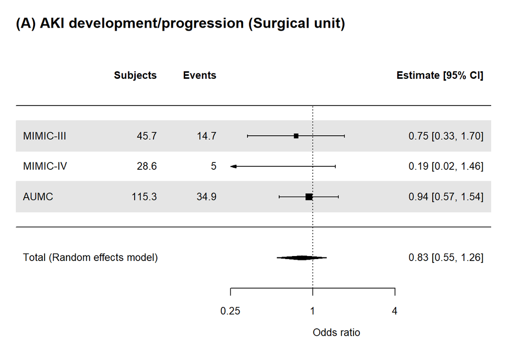

```r
#Forrestplot
FP2("wgt_man_Ovlp_MIMIC3_surg.rds", FORMULA_ovl2_surg)
FP2("wgt_man_Ovlp_MIMIC4_surg.rds", FORMULA_ovl2_surg)
FP2("wgt_man_Ovlp_AUMC_surg.rds", FORMULA_ovl2_surg)

surg_METADF0 <- rbind(
  readRDS("ORRES_wgt_man_Ovlp_MIMIC3_surg.rds") %>% mutate("dataset"="MIMIC-III"),
  readRDS("ORRES_wgt_man_Ovlp_MIMIC4_surg.rds") %>% mutate("dataset"="MIMIC-IV"),
  readRDS("ORRES_wgt_man_Ovlp_AUMC_surg.rds") %>% mutate("dataset"="AUMC"))
surg_METADF_AKID <- surg_METADF0 %>% subset(outcome=="outcome_KDIGO_inc_or_death")
surg_METADF_AKI <- surg_METADF0 %>% subset(outcome=="outcome_KDIGO_inc")
surg_METADF_HD <- surg_METADF0 %>% subset(outcome=="outcome_new_dial")
surg_METADF_D <- surg_METADF0 %>% subset(outcome=="death_in_7d")
surg_METADF_HDD <- surg_METADF0 %>% subset(outcome=="outcome_HDD_in7d")
surg_METARES_AKID <- rma(yi = Estimate, sei = Std.Error, method = "REML", data = surg_METADF_AKID)
surg_METARES_AKI <- rma(yi = Estimate, sei = Std.Error, method = "REML", data = surg_METADF_AKI)
surg_METARES_HD <- rma(yi = Estimate, sei = Std.Error, method = "REML", data = surg_METADF_HD)
surg_METARES_D <- rma(yi = Estimate, sei = Std.Error, method = "REML", data = surg_METADF_D)
surg_METARES_HDD <- rma(yi = Estimate, sei = Std.Error, method = "REML", data = surg_METADF_HDD)

METAF(surg_METARES_AKI, SCALEA1, SCALEB1, SCALEC1, "(A) AKI development/progression (Surgical unit)")
```

```r
surg_METARES_AKI
```

```
##
## Random-Effects Model (k = 3; tau^2 estimator: REML)
##
## tau^2 (estimated amount of total heterogeneity): 0.0000 (SE = 0.1636)
## tau (square root of estimated tau^2 value):      0.0009
## I^2 (total heterogeneity / total variability):   0.00%
## H^2 (total variability / sampling variability):  1.00
##
## Test for Heterogeneity:
## Q(df = 2) = 2.3090, p-val = 0.3152
##
## Model Results:
##
## estimate      se     zval    pval    ci.lb   ci.ub
##  -0.1869  0.2123  -0.8803  0.3787  -0.6029  0.2292
##
## ---
## Signif. codes:  0 '***' 0.001 '**' 0.01 '*' 0.05 '.' 0.1 ' ' 1
```

```r
surg_METADF_AKI %>% dplyr::select(dataset, OR, LCI, UCI, 'Pr(>|z|)') %>% remove_rownames()
```

```
##     dataset        OR        LCI      UCI  Pr(>|z|)
## 1 MIMIC-III 0.7543338 0.33441997 1.701512 0.4969590
## 2  MIMIC-IV 0.1850780 0.02342386 1.462349 0.1096866
## 3      AUMC 0.9378759 0.56995353 1.543303 0.8007375
```

__

__

#### 8d. Backgrounds, outcomes, matching quality, and forest plot among those **non-srugery**

```r
#1. overlap-PSM using MIMIC3, Older
OVLP(comb_DF2ovl %>% subset(dataset=="MIMIC3"&dep_type2=="Non-surgery"), FORMULA_ovl2_surg, "Ovlp_MIMIC3_nonsurg", "**Ovlp, MIMIC-III, Non-surgical unit**")
```

| **Characteristic** | **Ovlp, MIMIC-III, Non-surgical unit** **I/C** N=36.2<sup>1</sup> | **Ovlp, MIMIC-III, Non-surgical unit** **NCC** N=36.2<sup>1</sup> | **p-value**<sup>2</sup> |  |
| --- | --- | --- | --- | --- |
| dataset |  |  |  |  |
| MIMIC3 | 36.2 (100.0%) | 36.2 (100.0%) |  |  |
| age_group |  |  | 0.83 |  |
| 18-39 | 3.2 (8.9%) | 3.0 (8.3%) |  |  |
| 40-49 | 1.6 (4.3%) | 3.4 (9.4%) |  |  |
| 50-59 | 7.6 (21.0%) | 6.8 (18.9%) |  |  |
| 60-69 | 9.0 (24.8%) | 6.8 (18.7%) |  |  |
| 70-79 | 8.6 (23.9%) | 9.1 (25.2%) |  |  |
| 80+ | 6.2 (17.1%) | 7.1 (19.5%) |  |  |
| sex |  |  | >0.99 |  |
| Female | 19.7 (54.6%) | 19.7 (54.6%) |  |  |
| Male | 16.4 (45.4%) | 16.4 (45.4%) |  |  |
| bmi | 26.3 (24.5, 29.0) | 27.8 (23.9, 33.1) | 0.46 |  |
| Unknown | 18 | 24 |  |  |
| ICU type |  |  |  |  |
| Non-surgery | 36.2 (100.0%) | 36.2 (100.0%) |  |  |
| drug_name |  |  |  |  |
| Imipenem/cilastatin | 36.2 (100.0%) | 0.0 (0.0%) |  |  |
| Imipenem/cilastatin/relebactam | 0.0 (0.0%) | 0.0 (0.0%) |  |  |
| Meropenem | 0.0 (0.0%) | 36.2 (100.0%) |  |  |
| Doripenem | 0.0 (0.0%) | 0.0 (0.0%) |  |  |
| Ertapenem | 0.0 (0.0%) | 0.0 (0.0%) |  |  |
| sofa | 5.0 (3.0, 8.0) | 5.0 (3.0, 7.0) | 0.88 |  |
| qsofa | 1.0 (0.0, 1.0) | 1.0 (0.0, 1.0) | 0.65 |  |
| Unknown | 0 | 2 |  |  |
| sirs | 2.0 (1.0, 3.0) | 2.0 (1.0, 3.0) | 0.84 |  |
| pre_blood_culture | 30.1 (83.1%) | 30.1 (83.1%) | >0.99 |  |
| pre vancomycin use | 12.8 (35.5%) | 12.8 (35.5%) | >0.99 |  |
| pre vasopressor use | 14.5 (40.1%) | 14.5 (40.1%) | >0.99 |  |
| pre ventilation | 22.6 (62.4%) | 24.2 (66.9%) | 0.56 |  |
| Baseline sCr | 0.9 (0.6, 1.6) | 1.0 (0.6, 1.5) | 0.87 |  |
| sCr at treatment start | 1.1 (0.8, 1.9) | 1.2 (0.8, 1.8) | 0.85 |  |
| AKI stage at treatment start |  |  | 0.51 |  |
| 0 | 23.5 (64.8%) | 24.6 (68.1%) |  |  |
| 1 | 11.9 (32.8%) | 9.5 (26.4%) |  |  |
| 2 | 0.8 (2.3%) | 2.0 (5.5%) |  |  |
| observation time | 168.0 (142.4, 168.0) | 168.0 (160.5, 168.0) | 0.39 |  |
| Cencsored with drug change | 1.6 (4.4%) | 0.0 (0.0%) | 0.15 |  |
| RRT at treatment start | 0.0 (0.0%) | 0.0 (0.0%) |  |  |
| O, AKI develop/progress | 8.2 (22.6%) | 14.9 (41.3%) | 0.023 |  |
| O, Death | 5.4 (14.8%) | 6.5 (18.1%) | 0.60 |  |
| O, AKI d/p or death | 11.9 (33.0%) | 16.7 (46.3%) | 0.11 |  |
| O, RRT-intervention | 0.8 (2.2%) | 2.4 (6.7%) | 0.24 |  |
| O, Death or RRT-intervention | 6.1 (17.0%) | 8.5 (23.5%) | 0.34 |  |

<sup>1</sup> n (%); Median (Q1, Q3)  
<sup>2</sup> NA; Pearson’s X^2: Rao & Scott adjustment; Design-based KruskalWallis test

```r
#2. overlap-PSM using MIMIC4, Older
OVLP(comb_DF2ovl %>% subset(dataset=="miiv"&dep_type2=="Non-surgery"), FORMULA_ovl2_surg, "Ovlp_MIMIC4_nonsurg", "**Ovlp, MIMIC-IV, Non-surgical unit**")
```

| **Characteristic** | **Ovlp, MIMIC-IV, Non-surgical unit** **I/C** N=70.3<sup>1</sup> | **Ovlp, MIMIC-IV, Non-surgical unit** **NCC** N=70.3<sup>1</sup> | **p-value**<sup>2</sup> |  |
| --- | --- | --- | --- | --- |
| dataset |  |  |  |  |
| miiv | 70.3 (100.0%) | 70.3 (100.0%) |  |  |
| age_group |  |  | 0.64 |  |
| 18-39 | 5.8 (8.3%) | 4.8 (6.8%) |  |  |
| 40-49 | 6.8 (9.7%) | 6.3 (8.9%) |  |  |
| 50-59 | 8.7 (12.4%) | 13.7 (19.6%) |  |  |
| 60-69 | 20.2 (28.8%) | 18.0 (25.7%) |  |  |
| 70-79 | 17.3 (24.6%) | 14.6 (20.7%) |  |  |
| 80+ | 11.4 (16.2%) | 12.9 (18.3%) |  |  |
| sex |  |  | >0.99 |  |
| Female | 32.7 (46.5%) | 32.7 (46.5%) |  |  |
| Male | 37.6 (53.5%) | 37.6 (53.5%) |  |  |
| bmi | 27.1 (24.8, 31.4) | 27.4 (23.4, 33.1) | 0.82 |  |
| Unknown | 39 | 27 |  |  |
| ICU type |  |  |  |  |
| Non-surgery | 70.3 (100.0%) | 70.3 (100.0%) |  |  |
| drug_name |  |  |  |  |
| Imipenem/cilastatin | 70.3 (100.0%) | 0.0 (0.0%) |  |  |
| Imipenem/cilastatin/relebactam | 0.0 (0.0%) | 0.0 (0.0%) |  |  |
| Meropenem | 0.0 (0.0%) | 69.8 (99.2%) |  |  |
| Doripenem | 0.0 (0.0%) | 0.2 (0.2%) |  |  |
| Ertapenem | 0.0 (0.0%) | 0.4 (0.5%) |  |  |
| sofa | 5.0 (3.0, 8.0) | 6.0 (3.0, 9.0) | 0.34 |  |
| qsofa | 1.0 (0.0, 1.0) | 1.0 (0.0, 1.0) | 0.50 |  |
| Unknown | 0 | 0 |  |  |
| sirs | 2.0 (1.0, 3.0) | 2.0 (1.0, 3.0) | 0.92 |  |
| pre_blood_culture | 53.8 (76.6%) | 53.8 (76.6%) | >0.99 |  |
| pre vancomycin use | 42.6 (60.6%) | 42.6 (60.6%) | >0.99 |  |
| pre vasopressor use | 7.6 (10.8%) | 7.6 (10.8%) | >0.99 |  |
| pre ventilation | 11.5 (16.4%) | 6.9 (9.8%) | 0.068 |  |
| Baseline sCr | 1.0 (0.7, 1.6) | 1.0 (0.7, 1.5) | 0.98 |  |
| sCr at treatment start | 1.1 (0.7, 2.0) | 1.2 (0.7, 1.9) | 0.98 |  |
| AKI stage at treatment start |  |  | 0.98 |  |
| 0 | 54.8 (77.9%) | 55.0 (78.3%) |  |  |
| 1 | 12.6 (18.0%) | 12.1 (17.2%) |  |  |
| 2 | 2.9 (4.1%) | 3.1 (4.5%) |  |  |
| observation time | 168.0 (101.0, 168.0) | 168.0 (129.0, 168.0) | 0.54 |  |
| Unknown | 7 | 6 |  |  |
| Cencsored with drug change | 2.9 (4.1%) | 0.0 (0.0%) | 0.076 |  |
| RRT at treatment start | 0.0 (0.0%) | 0.0 (0.0%) |  |  |
| O, AKI develop/progress | 29.8 (42.4%) | 22.9 (32.6%) | 0.081 |  |
| O, Death | 12.5 (17.7%) | 11.9 (17.0%) | 0.86 |  |
| O, AKI d/p or death | 30.8 (43.7%) | 27.9 (39.6%) | 0.48 |  |
| O, RRT-intervention | 2.9 (4.1%) | 4.9 (6.9%) | 0.35 |  |
| O, Death or RRT-intervention | 13.4 (19.1%) | 15.0 (21.4%) | 0.65 |  |

<sup>1</sup> n (%); Median (Q1, Q3)  
<sup>2</sup> NA; Pearson’s X^2: Rao & Scott adjustment; Design-based KruskalWallis test

```r
#3. overlap-PSM using AUMC, Older
OVLP(comb_DF2ovl %>% subset(dataset=="AUMC"&dep_type2=="Non-surgery"), FORMULA_ovl2_surg, "Ovlp_AUMC_nonsurg", "**Ovlp, AUMC, Non-surgical unit**")
```

| **Characteristic** | **Ovlp, AUMC, Non-surgical unit** **I/C** N=84.7<sup>1</sup> | **Ovlp, AUMC, Non-surgical unit** **NCC** N=84.7<sup>1</sup> | **p-value**<sup>2</sup> |  |
| --- | --- | --- | --- | --- |
| dataset |  |  |  |  |
| AUMC | 84.7 (100.0%) | 84.7 (100.0%) |  |  |
| age_group |  |  | 0.72 |  |
| 18-39 | 11.6 (13.6%) | 14.3 (16.9%) |  |  |
| 40-49 | 10.2 (12.1%) | 7.0 (8.3%) |  |  |
| 50-59 | 18.4 (21.7%) | 16.4 (19.3%) |  |  |
| 60-69 | 24.2 (28.5%) | 24.3 (28.7%) |  |  |
| 70-79 | 16.6 (19.6%) | 19.9 (23.5%) |  |  |
| 80+ | 3.8 (4.5%) | 2.7 (3.2%) |  |  |
| sex |  |  | >0.99 |  |
| Female | 31.7 (37.4%) | 31.7 (37.4%) |  |  |
| Male | 53.0 (62.6%) | 53.0 (62.6%) |  |  |
| bmi | 24.5 (21.9, 27.8) | 24.8 (21.9, 27.8) | 0.11 |  |
| Unknown | 4 | 2 |  |  |
| ICU type |  |  |  |  |
| Non-surgery | 84.7 (100.0%) | 84.7 (100.0%) |  |  |
| drug_name |  |  |  |  |
| Imipenem/cilastatin | 84.7 (100.0%) | 0.0 (0.0%) |  |  |
| Imipenem/cilastatin/relebactam | 0.0 (0.0%) | 0.0 (0.0%) |  |  |
| Meropenem | 0.0 (0.0%) | 84.7 (100.0%) |  |  |
| Doripenem | 0.0 (0.0%) | 0.0 (0.0%) |  |  |
| Ertapenem | 0.0 (0.0%) | 0.0 (0.0%) |  |  |
| sofa | 7.0 (5.0, 9.0) | 7.0 (4.0, 9.0) | 0.46 |  |
| Unknown | 13 | 15 |  |  |
| qsofa | 1.0 (0.0, 1.0) | 1.0 (0.0, 1.0) | 0.71 |  |
| Unknown | 0 | 0 |  |  |
| sirs | 2.0 (1.0, 3.0) | 2.0 (1.0, 3.0) | 0.88 |  |
| pre_blood_culture | 11.6 (13.7%) | 11.6 (13.7%) | >0.99 |  |
| pre vancomycin use | 38.7 (45.7%) | 38.7 (45.7%) | >0.99 |  |
| pre vasopressor use | 57.0 (67.3%) | 57.0 (67.3%) | >0.99 |  |
| pre ventilation | 59.0 (69.7%) | 52.4 (61.9%) | 0.12 |  |
| Baseline sCr | 0.8 (0.6, 1.2) | 0.7 (0.6, 1.2) | 0.36 |  |
| sCr at treatment start | 1.0 (0.7, 1.5) | 0.9 (0.6, 1.5) | 0.53 |  |
| AKI stage at treatment start |  |  | 0.79 |  |
| 0 | 63.0 (74.4%) | 64.0 (75.5%) |  |  |
| 1 | 17.9 (21.1%) | 15.9 (18.8%) |  |  |
| 2 | 3.8 (4.5%) | 4.8 (5.6%) |  |  |
| observation time | 168.0 (65.8, 168.0) | 137.6 (53.6, 168.0) | 0.12 |  |
| Cencsored with drug change | 2.7 (3.2%) | 0.0 (0.0%) | 0.002 |  |
| RRT at treatment start | 0.0 (0.0%) | 0.0 (0.0%) |  |  |
| O, AKI develop/progress | 26.2 (30.9%) | 23.1 (27.3%) | 0.47 |  |
| O, Death | 10.9 (12.9%) | 10.9 (12.8%) | 0.98 |  |
| O, AKI d/p or death | 30.0 (35.5%) | 29.0 (34.3%) | 0.82 |  |
| O, RRT-intervention | 7.9 (9.3%) | 7.7 (9.1%) | 0.95 |  |
| O, Death or RRT-intervention | 16.2 (19.2%) | 15.5 (18.3%) | 0.84 |  |

<sup>1</sup> n (%); Median (Q1, Q3)  
<sup>2</sup> NA; Pearson’s X^2: Rao & Scott adjustment; Design-based KruskalWallis test

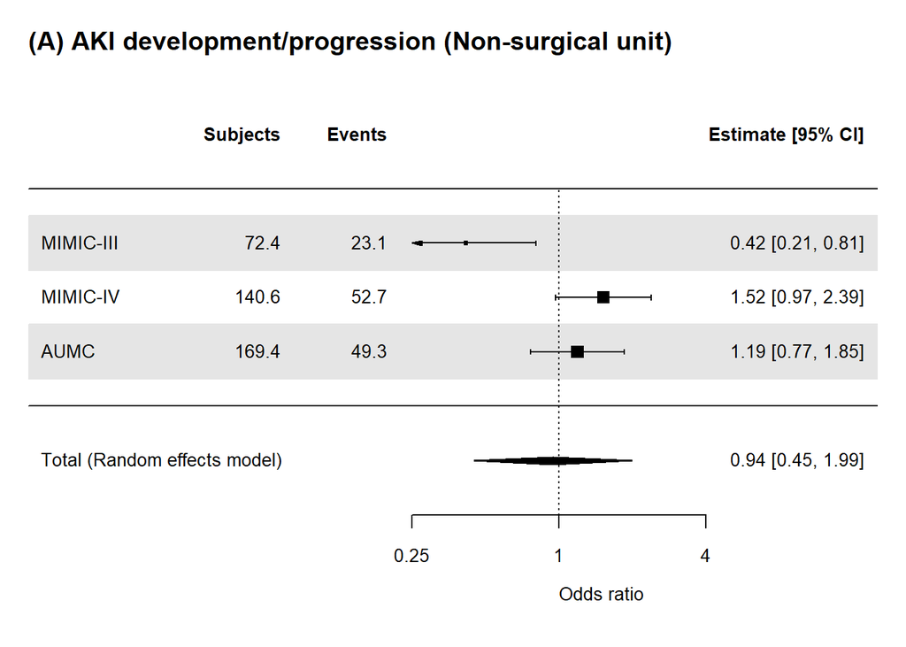

```r
FP2("wgt_man_Ovlp_MIMIC4_nonsurg.rds", FORMULA_ovl2_surg)
FP2("wgt_man_Ovlp_MIMIC3_nonsurg.rds", FORMULA_ovl2_surg)
FP2("wgt_man_Ovlp_AUMC_nonsurg.rds", FORMULA_ovl2_surg)

nonsurg_METADF0 <- rbind(
  readRDS("ORRES_wgt_man_Ovlp_MIMIC3_nonsurg.rds") %>% mutate("dataset"="MIMIC-III"),
  readRDS("ORRES_wgt_man_Ovlp_MIMIC4_nonsurg.rds") %>% mutate("dataset"="MIMIC-IV"),
  readRDS("ORRES_wgt_man_Ovlp_AUMC_nonsurg.rds") %>% mutate("dataset"="AUMC"))
nonsurg_METADF_AKID <- nonsurg_METADF0 %>% subset(outcome=="outcome_KDIGO_inc_or_death")
nonsurg_METADF_AKI <- nonsurg_METADF0 %>% subset(outcome=="outcome_KDIGO_inc")
nonsurg_METADF_HD <- nonsurg_METADF0 %>% subset(outcome=="outcome_new_dial")
nonsurg_METADF_D <- nonsurg_METADF0 %>% subset(outcome=="death_in_7d")
nonsurg_METADF_HDD <- nonsurg_METADF0 %>% subset(outcome=="outcome_HDD_in7d")

nonsurg_METARES_AKID <- rma(yi = Estimate, sei = Std.Error, method = "REML", data = nonsurg_METADF_AKID)
nonsurg_METARES_AKI <-rma(yi = Estimate, sei = Std.Error, method = "REML", data = nonsurg_METADF_AKI)
nonsurg_METARES_HD <- rma(yi = Estimate, sei = Std.Error, method = "REML", data = nonsurg_METADF_HD)
nonsurg_METARES_D <- rma(yi = Estimate, sei = Std.Error, method = "REML", data = nonsurg_METADF_D)
nonsurg_METARES_HDD <- rma(yi = Estimate, sei = Std.Error, method = "REML", data = nonsurg_METADF_HDD)

METAF(nonsurg_METARES_AKI, SCALEA1, SCALEB1, SCALEC1, "(A) AKI development/progression (Non-surgical unit)")
```

```r
nonsurg_METARES_AKI
```

```
##
## Random-Effects Model (k = 3; tau^2 estimator: REML)
##
## tau^2 (estimated amount of total heterogeneity): 0.3626 (SE = 0.4339)
## tau (square root of estimated tau^2 value):      0.6021
## I^2 (total heterogeneity / total variability):   84.44%
## H^2 (total variability / sampling variability):  6.42
##
## Test for Heterogeneity:
## Q(df = 2) = 10.3916, p-val = 0.0055
##
## Model Results:
##
## estimate      se     zval    pval    ci.lb   ci.ub
##  -0.0581  0.3801  -0.1528  0.8786  -0.8031  0.6870
##
## ---
## Signif. codes:  0 '***' 0.001 '**' 0.01 '*' 0.05 '.' 0.1 ' ' 1
```

```r
nonsurg_METADF_AKI %>% dplyr::select(dataset, OR, LCI, UCI, 'Pr(>|z|)') %>% remove_rownames()
```

```
##     dataset        OR       LCI       UCI    Pr(>|z|)
## 1 MIMIC-III 0.4155565 0.2139886 0.8069926 0.009507916
## 2  MIMIC-IV 1.5243949 0.9714981 2.3919549 0.066629521
## 3      AUMC 1.1913090 0.7651640 1.8547881 0.438352138
```

__

#### 9c. Backgrounds, outcomes, matching quality, and forrest plot among those **pre bood culture** at treatment start.

```r
FORMULA_ovl2_bc <- drug01 ~  age_cat + sex + sirs + dep_type2 + treat_van + vasopressor + base_crea + near_crea +  base_KDIGO
#1. overlap-PSM using MIMIC3, Older
OVLP(comb_DF2ovl %>% subset(dataset=="MIMIC3"&pre_blood_culture==T), FORMULA_ovl2_bc, "Ovlp_MIMIC3_bc", "**Ovlp, MIMIC-III, pre BC**")
```

| **Characteristic** | **Ovlp, MIMIC-III, pre BC** **I/C** N=48.3<sup>1</sup> | **Ovlp, MIMIC-III, pre BC** **NCC** N=48.3<sup>1</sup> | **p-value**<sup>2</sup> |  |
| --- | --- | --- | --- | --- |
| dataset |  |  |  |  |
| MIMIC3 | 48.3 (100.0%) | 48.3 (100.0%) |  |  |
| age_group |  |  | 0.56 |  |
| 18-39 | 3.4 (7.1%) | 4.2 (8.7%) |  |  |
| 40-49 | 4.0 (8.2%) | 4.6 (9.5%) |  |  |
| 50-59 | 9.9 (20.5%) | 8.2 (17.0%) |  |  |
| 60-69 | 12.1 (25.0%) | 8.8 (18.2%) |  |  |
| 70-79 | 9.5 (19.6%) | 14.5 (30.0%) |  |  |
| 80+ | 9.5 (19.6%) | 8.1 (16.7%) |  |  |
| sex |  |  | >0.99 |  |
| Female | 24.3 (50.3%) | 24.3 (50.3%) |  |  |
| Male | 24.0 (49.7%) | 24.0 (49.7%) |  |  |
| bmi | 26.3 (24.5, 29.2) | 27.7 (23.4, 33.1) | 0.93 |  |
| Unknown | 21 | 25 |  |  |
| ICU type |  |  | >0.99 |  |
| Non-surgery | 30.3 (62.6%) | 30.3 (62.6%) |  |  |
| Surgery | 18.1 (37.4%) | 18.1 (37.4%) |  |  |
| drug_name |  |  |  |  |
| Imipenem/cilastatin | 48.3 (100.0%) | 0.0 (0.0%) |  |  |
| Imipenem/cilastatin/relebactam | 0.0 (0.0%) | 0.0 (0.0%) |  |  |
| Meropenem | 0.0 (0.0%) | 48.3 (100.0%) |  |  |
| Doripenem | 0.0 (0.0%) | 0.0 (0.0%) |  |  |
| Ertapenem | 0.0 (0.0%) | 0.0 (0.0%) |  |  |
| sofa | 5.0 (3.0, 9.0) | 4.0 (2.0, 7.0) | 0.36 |  |
| qsofa | 1.0 (0.0, 1.0) | 1.0 (0.0, 1.0) | 0.51 |  |
| Unknown | 0 | 1 |  |  |
| sirs | 2.0 (1.0, 3.0) | 2.0 (1.0, 3.0) | 0.93 |  |
| pre_blood_culture | 48.3 (100.0%) | 48.3 (100.0%) |  |  |
| pre vancomycin use | 16.4 (33.9%) | 16.4 (33.9%) | >0.99 |  |
| pre vasopressor use | 22.9 (47.3%) | 22.9 (47.3%) | >0.99 |  |
| pre ventilation | 32.1 (66.5%) | 33.7 (69.8%) | 0.62 |  |
| Baseline sCr | 0.9 (0.6, 1.3) | 0.9 (0.6, 1.4) | 0.96 |  |
| sCr at treatment start | 1.1 (0.8, 1.7) | 1.0 (0.7, 1.7) | 0.85 |  |
| AKI stage at treatment start |  |  | 0.83 |  |
| 0 | 35.9 (74.3%) | 35.4 (73.2%) |  |  |
| 1 | 10.8 (22.4%) | 11.9 (24.6%) |  |  |
| 2 | 1.6 (3.3%) | 1.0 (2.1%) |  |  |
| observation time | 168.0 (168.0, 168.0) | 168.0 (168.0, 168.0) | 0.84 |  |
| Cencsored with drug change | 2.4 (5.0%) | 0.2 (0.5%) | 0.011 |  |
| RRT at treatment start | 0.0 (0.0%) | 0.0 (0.0%) |  |  |
| O, AKI develop/progress | 12.0 (24.8%) | 18.9 (39.1%) | 0.039 |  |
| O, Death | 4.7 (9.8%) | 7.4 (15.3%) | 0.27 |  |
| O, AKI d/p or death | 13.6 (28.2%) | 21.1 (43.6%) | 0.031 |  |
| O, RRT-intervention | 0.8 (1.7%) | 2.3 (4.7%) | 0.30 |  |
| O, Death or RRT-intervention | 5.6 (11.5%) | 9.2 (19.0%) | 0.17 |  |

<sup>1</sup> n (%); Median (Q1, Q3)  
<sup>2</sup> NA; Pearson’s X^2: Rao & Scott adjustment; Design-based KruskalWallis test

```r
#2. overlap-PSM using MIMIC4, Older
OVLP(comb_DF2ovl %>% subset(dataset=="miiv"&pre_blood_culture==T), FORMULA_ovl2_bc, "Ovlp_MIMIC4_bc", "**Ovlp, MIMIC-IV, pre BC**")
```

| **Characteristic** | **Ovlp, MIMIC-IV, pre BC** **I/C** N=65.6<sup>1</sup> | **Ovlp, MIMIC-IV, pre BC** **NCC** N=65.6<sup>1</sup> | **p-value**<sup>2</sup> |  |
| --- | --- | --- | --- | --- |
| dataset |  |  |  |  |
| miiv | 65.6 (100.0%) | 65.6 (100.0%) |  |  |
| age_group |  |  | 0.23 |  |
| 18-39 | 4.9 (7.4%) | 4.6 (7.0%) |  |  |
| 40-49 | 7.8 (11.9%) | 5.7 (8.7%) |  |  |
| 50-59 | 5.8 (8.9%) | 12.6 (19.2%) |  |  |
| 60-69 | 22.2 (33.8%) | 17.4 (26.6%) |  |  |
| 70-79 | 15.4 (23.4%) | 14.5 (22.1%) |  |  |
| 80+ | 9.5 (14.5%) | 10.8 (16.5%) |  |  |
| sex |  |  | >0.99 |  |
| Female | 29.8 (45.4%) | 29.8 (45.4%) |  |  |
| Male | 35.8 (54.6%) | 35.8 (54.6%) |  |  |
| bmi | 30.0 (25.2, 36.1) | 27.5 (23.6, 33.2) | 0.12 |  |
| Unknown | 35 | 23 |  |  |
| ICU type |  |  | >0.99 |  |
| Non-surgery | 53.8 (82.1%) | 53.8 (82.1%) |  |  |
| Surgery | 11.8 (17.9%) | 11.8 (17.9%) |  |  |
| drug_name |  |  | <0.001 |  |
| Imipenem/cilastatin | 64.6 (98.5%) | 0.0 (0.0%) |  |  |
| Imipenem/cilastatin/relebactam | 1.0 (1.5%) | 0.0 (0.0%) |  |  |
| Meropenem | 0.0 (0.0%) | 65.2 (99.4%) |  |  |
| Doripenem | 0.0 (0.0%) | 0.2 (0.3%) |  |  |
| Ertapenem | 0.0 (0.0%) | 0.2 (0.4%) |  |  |
| sofa | 5.0 (3.0, 8.0) | 6.0 (3.0, 9.0) | 0.41 |  |
| qsofa | 1.0 (0.0, 1.0) | 1.0 (0.0, 1.0) | 0.62 |  |
| Unknown | 0 | 0 |  |  |
| sirs | 2.0 (1.0, 3.0) | 2.0 (1.0, 3.0) | >0.99 |  |
| pre_blood_culture | 65.6 (100.0%) | 65.6 (100.0%) |  |  |
| pre vancomycin use | 40.7 (62.1%) | 40.7 (62.1%) | >0.99 |  |
| pre vasopressor use | 7.6 (11.6%) | 7.6 (11.6%) | >0.99 |  |
| pre ventilation | 10.5 (16.0%) | 7.1 (10.8%) | 0.17 |  |
| Baseline sCr | 1.0 (0.6, 1.5) | 0.9 (0.6, 1.4) | 0.76 |  |
| sCr at treatment start | 1.1 (0.7, 2.0) | 1.1 (0.7, 1.7) | 0.94 |  |
| AKI stage at treatment start |  |  | 0.97 |  |
| 0 | 49.0 (74.8%) | 48.7 (74.3%) |  |  |
| 1 | 12.7 (19.3%) | 13.3 (20.3%) |  |  |
| 2 | 3.9 (5.9%) | 3.6 (5.4%) |  |  |
| observation time | 168.0 (101.0, 168.0) | 168.0 (152.3, 168.0) | 0.22 |  |
| Unknown | 7 | 7 |  |  |
| Cencsored with drug change | 2.9 (4.4%) | 0.0 (0.0%) | 0.076 |  |
| RRT at treatment start | 0.0 (0.0%) | 0.0 (0.0%) |  |  |
| O, AKI develop/progress | 24.9 (38.0%) | 22.9 (34.9%) | 0.59 |  |
| O, Death | 12.5 (19.0%) | 11.3 (17.3%) | 0.71 |  |
| O, AKI d/p or death | 26.9 (41.0%) | 27.2 (41.5%) | 0.93 |  |
| O, RRT-intervention | 2.9 (4.4%) | 4.7 (7.1%) | 0.39 |  |
| O, Death or RRT-intervention | 13.4 (20.5%) | 14.2 (21.6%) | 0.82 |  |

<sup>1</sup> n (%); Median (Q1, Q3)  
<sup>2</sup> NA; Pearson’s X^2: Rao & Scott adjustment; Design-based KruskalWallis test

```r
#3. overlap-PSM using AUMC, Older
OVLP(comb_DF2ovl %>% subset(dataset=="AUMC"&pre_blood_culture==T), FORMULA_ovl2_bc, "Ovlp_AUMC_bc", "**Ovlp, AUMC, pre BC**")
```

| **Characteristic** | **Ovlp, AUMC, pre BC** **I/C** N=19.9<sup>1</sup> | **Ovlp, AUMC, pre BC** **NCC** N=19.9<sup>1</sup> | **p-value**<sup>2</sup> |  |
| --- | --- | --- | --- | --- |
| dataset |  |  |  |  |
| AUMC | 19.9 (100.0%) | 19.9 (100.0%) |  |  |
| age_group |  |  | 0.92 |  |
| 18-39 | 1.6 (8.3%) | 1.0 (5.0%) |  |  |
| 40-49 | 2.1 (10.4%) | 2.7 (13.5%) |  |  |
| 50-59 | 3.8 (18.8%) | 5.0 (25.1%) |  |  |
| 60-69 | 7.3 (36.6%) | 5.7 (28.6%) |  |  |
| 70-79 | 4.5 (22.5%) | 5.0 (25.3%) |  |  |
| 80+ | 0.7 (3.4%) | 0.5 (2.5%) |  |  |
| sex |  |  | >0.99 |  |
| Female | 8.4 (42.2%) | 8.4 (42.2%) |  |  |
| Male | 11.5 (57.8%) | 11.5 (57.8%) |  |  |
| bmi | 24.5 (22.2, 27.8) | 27.5 (23.9, 27.8) | 0.11 |  |
| Unknown | 2 | 1 |  |  |
| ICU type |  |  | >0.99 |  |
| Non-surgery | 11.3 (56.5%) | 11.3 (56.5%) |  |  |
| Surgery | 8.7 (43.5%) | 8.7 (43.5%) |  |  |
| drug_name |  |  |  |  |
| Imipenem/cilastatin | 19.9 (100.0%) | 0.0 (0.0%) |  |  |
| Imipenem/cilastatin/relebactam | 0.0 (0.0%) | 0.0 (0.0%) |  |  |
| Meropenem | 0.0 (0.0%) | 19.9 (100.0%) |  |  |
| Doripenem | 0.0 (0.0%) | 0.0 (0.0%) |  |  |
| Ertapenem | 0.0 (0.0%) | 0.0 (0.0%) |  |  |
| sofa | 8.0 (5.0, 10.0) | 8.0 (5.0, 9.0) | 0.85 |  |
| qsofa | 1.0 (1.0, 1.0) | 1.0 (0.0, 2.0) | 0.99 |  |
| sirs | 2.0 (2.0, 3.0) | 2.0 (2.0, 3.0) | 0.89 |  |
| pre_blood_culture | 19.9 (100.0%) | 19.9 (100.0%) |  |  |
| pre vancomycin use | 9.9 (49.7%) | 9.9 (49.7%) | >0.99 |  |
| pre vasopressor use | 13.0 (65.1%) | 13.0 (65.1%) | >0.99 |  |
| pre ventilation | 13.3 (66.6%) | 13.5 (68.0%) | 0.90 |  |
| Baseline sCr | 0.9 (0.6, 1.2) | 0.8 (0.5, 1.1) | 0.68 |  |
| sCr at treatment start | 1.0 (0.7, 1.5) | 0.9 (0.6, 1.7) | 0.52 |  |
| AKI stage at treatment start |  |  | 0.58 |  |
| 0 | 15.3 (76.9%) | 16.0 (80.3%) |  |  |
| 1 | 3.7 (18.8%) | 2.4 (12.0%) |  |  |
| 2 | 0.9 (4.3%) | 1.5 (7.7%) |  |  |
| observation time | 168.0 (82.5, 168.0) | 168.0 (77.0, 168.0) | 0.97 |  |
| Cencsored with drug change | 0.3 (1.3%) | 0.0 (0.0%) | 0.32 |  |
| RRT at treatment start | 0.0 (0.0%) | 0.0 (0.0%) |  |  |
| O, AKI develop/progress | 7.9 (39.4%) | 6.9 (34.8%) | 0.68 |  |
| O, Death | 2.8 (14.2%) | 3.6 (18.2%) | 0.63 |  |
| O, AKI d/p or death | 9.1 (45.6%) | 9.5 (47.5%) | 0.87 |  |
| O, RRT-intervention | 1.3 (6.8%) | 3.2 (16.2%) | 0.14 |  |
| O, Death or RRT-intervention | 3.9 (19.5%) | 6.3 (31.5%) | 0.22 |  |

<sup>1</sup> n (%); Median (Q1, Q3)  
<sup>2</sup> NA; Pearson’s X^2: Rao & Scott adjustment; Design-based KruskalWallis test

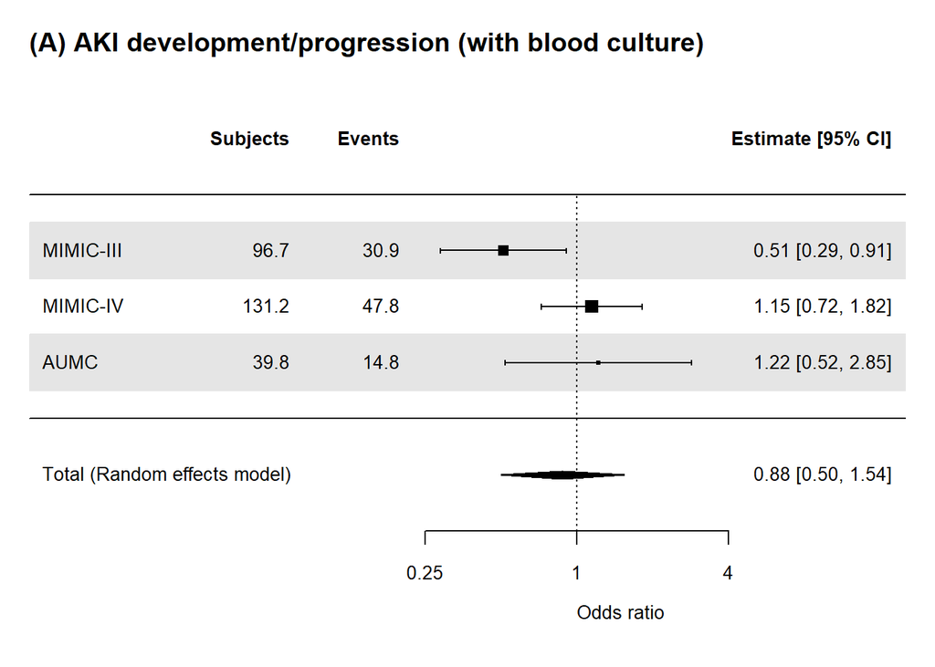

```r
#Forrestplot
FP2("wgt_man_Ovlp_MIMIC3_bc.rds", FORMULA_ovl2_bc)
FP2("wgt_man_Ovlp_MIMIC4_bc.rds", FORMULA_ovl2_bc)
FP2("wgt_man_Ovlp_AUMC_bc.rds", FORMULA_ovl2_bc)

bc_METADF0 <- rbind(
  readRDS("ORRES_wgt_man_Ovlp_MIMIC3_bc.rds") %>% mutate("dataset"="MIMIC-III"),
  readRDS("ORRES_wgt_man_Ovlp_MIMIC4_bc.rds") %>% mutate("dataset"="MIMIC-IV"),
  readRDS("ORRES_wgt_man_Ovlp_AUMC_bc.rds") %>% mutate("dataset"="AUMC"))
bc_METADF_AKID <- bc_METADF0 %>% subset(outcome=="outcome_KDIGO_inc_or_death")
bc_METADF_AKI <- bc_METADF0 %>% subset(outcome=="outcome_KDIGO_inc")
bc_METADF_HD <- bc_METADF0 %>% subset(outcome=="outcome_new_dial")
bc_METADF_D <- bc_METADF0 %>% subset(outcome=="death_in_7d")
bc_METADF_HDD <- bc_METADF0 %>% subset(outcome=="outcome_HDD_in7d")
bc_METARES_AKID <- rma(yi = Estimate, sei = Std.Error, method = "REML", data = bc_METADF_AKID)
bc_METARES_AKI <- rma(yi = Estimate, sei = Std.Error, method = "REML", data = bc_METADF_AKI)
bc_METARES_HD <- rma(yi = Estimate, sei = Std.Error, method = "REML", data = bc_METADF_HD)
bc_METARES_D <- rma(yi = Estimate, sei = Std.Error, method = "REML", data = bc_METADF_D)
bc_METARES_HDD <- rma(yi = Estimate, sei = Std.Error, method = "REML", data = bc_METADF_HDD)

METAF(bc_METARES_AKI, SCALEA1, SCALEB1, SCALEC1, "(A) AKI development/progression (with blood culture)")
```

```r
bc_METARES_AKI
```

```
##
## Random-Effects Model (k = 3; tau^2 estimator: REML)
##
## tau^2 (estimated amount of total heterogeneity): 0.1482 (SE = 0.2490)
## tau (square root of estimated tau^2 value):      0.3849
## I^2 (total heterogeneity / total variability):   60.84%
## H^2 (total variability / sampling variability):  2.55
##
## Test for Heterogeneity:
## Q(df = 2) = 5.2099, p-val = 0.0739
##
## Model Results:
##
## estimate      se     zval    pval    ci.lb   ci.ub
##  -0.1308  0.2869  -0.4558  0.6485  -0.6931  0.4316
##
## ---
## Signif. codes:  0 '***' 0.001 '**' 0.01 '*' 0.05 '.' 0.1 ' ' 1
```

```r
bc_METADF_AKI %>% dplyr::select(dataset, OR, LCI, UCI, 'Pr(>|z|)') %>% remove_rownames()
```

```
##     dataset        OR       LCI       UCI   Pr(>|z|)
## 1 MIMIC-III 0.5122321 0.2877005 0.9119959 0.02302888
## 2  MIMIC-IV 1.1463557 0.7234288 1.8165319 0.56087549
## 3      AUMC 1.2190640 0.5207773 2.8536517 0.64805100
```

__

__

#### 9d. Backgrounds, outcomes, matching quality, and forest plot among those **non-blood culture**

```r
#1. overlap-PSM using MIMIC3, Older
OVLP(comb_DF2ovl %>% subset(dataset=="MIMIC3"&pre_blood_culture==F), FORMULA_ovl2_bc, "Ovlp_MIMIC3_nonbc", "**Ovlp, MIMIC-III, Non-BC**")
```

| **Characteristic** | **Ovlp, MIMIC-III, Non-BC** **I/C** N=10.2<sup>1</sup> | **Ovlp, MIMIC-III, Non-BC** **NCC** N=10.2<sup>1</sup> | **p-value**<sup>2</sup> |  |
| --- | --- | --- | --- | --- |
| dataset |  |  |  |  |
| MIMIC3 | 10.2 (100.0%) | 10.2 (100.0%) |  |  |
| age_group |  |  | 0.27 |  |
| 18-39 | 0.0 (0.0%) | 0.2 (1.9%) |  |  |
| 40-49 | 2.3 (22.9%) | 0.5 (5.3%) |  |  |
| 50-59 | 0.5 (5.2%) | 1.5 (15.1%) |  |  |
| 60-69 | 1.2 (11.9%) | 2.9 (28.2%) |  |  |
| 70-79 | 3.4 (33.7%) | 3.1 (30.9%) |  |  |
| 80+ | 2.7 (26.3%) | 1.9 (18.5%) |  |  |
| sex |  |  | >0.99 |  |
| Female | 3.8 (37.5%) | 3.8 (37.5%) |  |  |
| Male | 6.3 (62.5%) | 6.3 (62.5%) |  |  |
| bmi | 31.6 (26.4, 34.6) | 29.3 (20.2, 40.8) | 0.58 |  |
| Unknown | 6 | 7 |  |  |
| ICU type |  |  | >0.99 |  |
| Non-surgery | 4.8 (47.4%) | 4.8 (47.4%) |  |  |
| Surgery | 5.3 (52.6%) | 5.3 (52.6%) |  |  |
| drug_name |  |  |  |  |
| Imipenem/cilastatin | 10.2 (100.0%) | 0.0 (0.0%) |  |  |
| Imipenem/cilastatin/relebactam | 0.0 (0.0%) | 0.0 (0.0%) |  |  |
| Meropenem | 0.0 (0.0%) | 10.2 (100.0%) |  |  |
| Doripenem | 0.0 (0.0%) | 0.0 (0.0%) |  |  |
| Ertapenem | 0.0 (0.0%) | 0.0 (0.0%) |  |  |
| sofa | 3.0 (2.0, 6.0) | 3.0 (2.0, 7.0) | 0.73 |  |
| qsofa | 1.0 (0.0, 1.0) | 0.0 (0.0, 1.0) | 0.25 |  |
| Unknown | 0 | 0 |  |  |
| sirs | 2.0 (1.0, 3.0) | 2.0 (1.0, 2.0) | 0.89 |  |
| pre_blood_culture | 0.0 (0.0%) | 0.0 (0.0%) |  |  |
| pre vancomycin use | 2.2 (21.6%) | 2.2 (21.6%) | >0.99 |  |
| pre vasopressor use | 1.4 (13.8%) | 1.4 (13.8%) | >0.99 |  |
| pre ventilation | 6.9 (68.3%) | 5.7 (56.1%) | 0.44 |  |
| Baseline sCr | 0.9 (0.6, 1.5) | 0.9 (0.6, 1.6) | 0.97 |  |
| sCr at treatment start | 1.1 (0.7, 1.9) | 1.0 (0.7, 1.7) | 0.96 |  |
| AKI stage at treatment start |  |  | 0.38 |  |
| 0 | 8.2 (81.0%) | 8.6 (84.7%) |  |  |
| 1 | 1.9 (19.0%) | 1.2 (11.5%) |  |  |
| 2 | 0.0 (0.0%) | 0.4 (3.8%) |  |  |
| observation time | 168.0 (72.3, 168.0) | 168.0 (149.4, 168.0) | 0.38 |  |
| Cencsored with drug change | 0.0 (0.0%) | 0.0 (0.0%) |  |  |
| RRT at treatment start | 0.0 (0.0%) | 0.0 (0.0%) |  |  |
| O, AKI develop/progress | 2.7 (26.4%) | 4.2 (41.8%) | 0.33 |  |
| O, Death | 2.2 (22.1%) | 1.5 (14.4%) | 0.51 |  |
| O, AKI d/p or death | 4.1 (40.1%) | 5.0 (49.5%) | 0.55 |  |
| O, RRT-intervention | 0.8 (8.4%) | 0.6 (5.5%) | 0.75 |  |
| O, Death or RRT-intervention | 2.2 (22.1%) | 2.0 (19.9%) | 0.86 |  |

<sup>1</sup> n (%); Median (Q1, Q3)  
<sup>2</sup> NA; Pearson’s X^2: Rao & Scott adjustment; Design-based KruskalWallis test

```r
#2. overlap-PSM using MIMIC4, Older
OVLP(comb_DF2ovl %>% subset(dataset=="miiv"&pre_blood_culture==F), FORMULA_ovl2_bc, "Ovlp_MIMIC4_nonbc", "**Ovlp, MIMIC-IV, Non-BC**")
```

| **Characteristic** | **Ovlp, MIMIC-IV, Non-BC** **I/C** N=18.9<sup>1</sup> | **Ovlp, MIMIC-IV, Non-BC** **NCC** N=18.9<sup>1</sup> | **p-value**<sup>2</sup> |  |
| --- | --- | --- | --- | --- |
| dataset |  |  |  |  |
| miiv | 18.9 (100.0%) | 18.9 (100.0%) |  |  |
| age_group |  |  | 0.55 |  |
| 18-39 | 2.8 (15.0%) | 1.8 (9.7%) |  |  |
| 40-49 | 1.8 (9.4%) | 2.1 (11.2%) |  |  |
| 50-59 | 4.8 (25.4%) | 4.2 (22.2%) |  |  |
| 60-69 | 1.8 (9.5%) | 4.6 (24.3%) |  |  |
| 70-79 | 2.8 (15.0%) | 3.2 (16.9%) |  |  |
| 80+ | 4.9 (25.7%) | 3.0 (15.7%) |  |  |
| sex |  |  | >0.99 |  |
| Female | 6.6 (35.1%) | 6.6 (35.1%) |  |  |
| Male | 12.3 (64.9%) | 12.3 (64.9%) |  |  |
| bmi | 25.3 (23.0, 28.2) | 27.4 (23.1, 33.4) | 0.38 |  |
| Unknown | 7 | 9 |  |  |
| ICU type |  |  | >0.99 |  |
| Non-surgery | 16.0 (84.7%) | 16.0 (84.7%) |  |  |
| Surgery | 2.9 (15.3%) | 2.9 (15.3%) |  |  |
| drug_name |  |  |  |  |
| Imipenem/cilastatin | 18.9 (100.0%) | 0.0 (0.0%) |  |  |
| Imipenem/cilastatin/relebactam | 0.0 (0.0%) | 0.0 (0.0%) |  |  |
| Meropenem | 0.0 (0.0%) | 18.8 (99.4%) |  |  |
| Doripenem | 0.0 (0.0%) | 0.0 (0.0%) |  |  |
| Ertapenem | 0.0 (0.0%) | 0.1 (0.6%) |  |  |
| sofa | 4.0 (2.0, 6.0) | 5.0 (3.0, 7.0) | 0.31 |  |
| qsofa | 1.0 (0.0, 1.0) | 1.0 (0.0, 1.0) | >0.99 |  |
| Unknown | 0 | 0 |  |  |
| sirs | 1.0 (1.0, 2.0) | 1.0 (0.0, 2.0) | 0.88 |  |
| pre_blood_culture | 0.0 (0.0%) | 0.0 (0.0%) |  |  |
| pre vancomycin use | 11.3 (59.8%) | 11.3 (59.8%) | >0.99 |  |
| pre vasopressor use | 0.0 (0.0%) | 0.0 (0.0%) | <0.001 |  |
| pre ventilation | 0.9 (5.0%) | 0.2 (1.0%) | 0.12 |  |
| Baseline sCr | 1.0 (0.6, 1.5) | 1.1 (0.7, 1.8) | 0.70 |  |
| sCr at treatment start | 1.3 (0.7, 1.7) | 1.3 (0.8, 2.1) | 0.77 |  |
| AKI stage at treatment start |  |  | 0.99 |  |
| 0 | 15.3 (80.7%) | 15.2 (80.2%) |  |  |
| 1 | 2.7 (14.3%) | 2.9 (15.4%) |  |  |
| 2 | 0.9 (5.0%) | 0.8 (4.4%) |  |  |
| observation time | 168.0 (139.0, 168.0) | 168.0 (126.1, 168.0) | 0.90 |  |
| Unknown | 2 | 1 |  |  |
| Cencsored with drug change | 1.0 (5.2%) | 0.0 (0.0%) | 0.30 |  |
| RRT at treatment start | 0.0 (0.0%) | 0.0 (0.0%) |  |  |
| O, AKI develop/progress | 5.6 (29.6%) | 4.5 (23.9%) | 0.56 |  |
| O, Death | 0.9 (5.0%) | 0.9 (4.6%) | 0.93 |  |
| O, AKI d/p or death | 5.6 (29.6%) | 5.1 (26.8%) | 0.79 |  |
| O, RRT-intervention | 0.0 (0.0%) | 1.0 (5.1%) | <0.001 |  |
| O, Death or RRT-intervention | 0.9 (5.0%) | 1.8 (9.3%) | 0.51 |  |

<sup>1</sup> n (%); Median (Q1, Q3)  
<sup>2</sup> NA; Pearson’s X^2: Rao & Scott adjustment; Design-based KruskalWallis test

```r
#3. overlap-PSM using AUMC, Older
OVLP(comb_DF2ovl %>% subset(dataset=="AUMC"&pre_blood_culture==F), FORMULA_ovl2_bc, "Ovlp_AUMC_nonbc", "**Ovlp, AUMC, Non-BC**")
```

| **Characteristic** | **Ovlp, AUMC, Non-BC** **I/C** N=122.8<sup>1</sup> | **Ovlp, AUMC, Non-BC** **NCC** N=122.8<sup>1</sup> | **p-value**<sup>2</sup> |  |
| --- | --- | --- | --- | --- |
| dataset |  |  |  |  |
| AUMC | 122.8 (100.0%) | 122.8 (100.0%) |  |  |
| age_group |  |  | 0.45 |  |
| 18-39 | 14.4 (11.7%) | 18.7 (15.3%) |  |  |
| 40-49 | 13.2 (10.8%) | 12.4 (10.1%) |  |  |
| 50-59 | 27.1 (22.0%) | 20.2 (16.4%) |  |  |
| 60-69 | 38.1 (31.0%) | 35.2 (28.7%) |  |  |
| 70-79 | 24.8 (20.2%) | 30.7 (25.0%) |  |  |
| 80+ | 5.2 (4.2%) | 5.6 (4.6%) |  |  |
| sex |  |  | >0.99 |  |
| Female | 43.5 (35.5%) | 43.5 (35.5%) |  |  |
| Male | 79.3 (64.5%) | 79.3 (64.5%) |  |  |
| bmi | 24.5 (21.9, 27.8) | 24.5 (21.3, 27.8) | 0.76 |  |
| Unknown | 6 | 3 |  |  |
| ICU type |  |  | >0.99 |  |
| Non-surgery | 73.6 (59.9%) | 73.6 (59.9%) |  |  |
| Surgery | 49.2 (40.1%) | 49.2 (40.1%) |  |  |
| drug_name |  |  |  |  |
| Imipenem/cilastatin | 122.8 (100.0%) | 0.0 (0.0%) |  |  |
| Imipenem/cilastatin/relebactam | 0.0 (0.0%) | 0.0 (0.0%) |  |  |
| Meropenem | 0.0 (0.0%) | 122.8 (100.0%) |  |  |
| Doripenem | 0.0 (0.0%) | 0.0 (0.0%) |  |  |
| Ertapenem | 0.0 (0.0%) | 0.0 (0.0%) |  |  |
| sofa | 7.0 (5.0, 9.0) | 7.0 (4.0, 9.0) | 0.52 |  |
| Unknown | 20 | 25 |  |  |
| qsofa | 1.0 (0.0, 1.0) | 1.0 (0.0, 1.0) | 0.95 |  |
| Unknown | 0 | 0 |  |  |
| sirs | 2.0 (1.0, 3.0) | 2.0 (1.0, 3.0) | 0.88 |  |
| pre_blood_culture | 0.0 (0.0%) | 0.0 (0.0%) |  |  |
| pre vancomycin use | 61.5 (50.1%) | 61.5 (50.1%) | >0.99 |  |
| pre vasopressor use | 77.6 (63.2%) | 77.6 (63.2%) | >0.99 |  |
| pre ventilation | 82.6 (67.3%) | 70.8 (57.6%) | 0.026 |  |
| Baseline sCr | 0.8 (0.6, 1.2) | 0.7 (0.6, 1.2) | 0.27 |  |
| sCr at treatment start | 1.0 (0.7, 1.4) | 0.9 (0.6, 1.5) | 0.36 |  |
| AKI stage at treatment start |  |  | 0.92 |  |
| 0 | 89.0 (72.5%) | 89.7 (73.1%) |  |  |
| 1 | 26.8 (21.8%) | 25.3 (20.6%) |  |  |
| 2 | 7.0 (5.7%) | 7.8 (6.3%) |  |  |
| observation time | 168.0 (55.8, 168.0) | 146.6 (56.4, 168.0) | 0.58 |  |
| Cencsored with drug change | 4.2 (3.4%) | 1.4 (1.2%) | 0.14 |  |
| RRT at treatment start | 0.0 (0.0%) | 0.0 (0.0%) |  |  |
| O, AKI develop/progress | 35.3 (28.8%) | 34.2 (27.9%) | 0.83 |  |
| O, Death | 17.0 (13.8%) | 14.9 (12.2%) | 0.59 |  |
| O, AKI d/p or death | 41.6 (33.9%) | 40.8 (33.2%) | 0.87 |  |
| O, RRT-intervention | 12.0 (9.7%) | 12.8 (10.4%) | 0.81 |  |
| O, Death or RRT-intervention | 24.4 (19.9%) | 21.4 (17.4%) | 0.49 |  |

<sup>1</sup> n (%); Median (Q1, Q3)  
<sup>2</sup> NA; Pearson’s X^2: Rao & Scott adjustment; Design-based KruskalWallis test

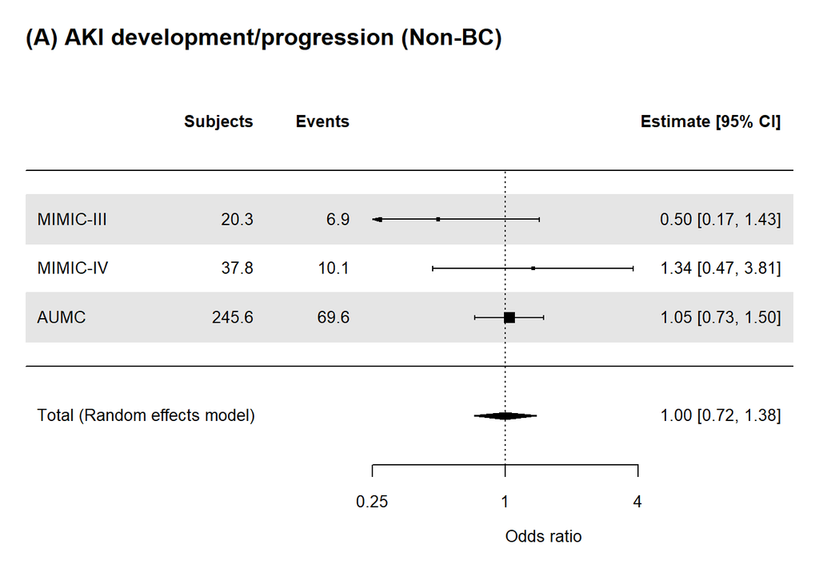

```r
FP2("wgt_man_Ovlp_MIMIC4_nonbc.rds", FORMULA_ovl2_bc)
FP2("wgt_man_Ovlp_MIMIC3_nonbc.rds", FORMULA_ovl2_bc)
FP2("wgt_man_Ovlp_AUMC_nonbc.rds", FORMULA_ovl2_bc)

nonbc_METADF0 <- rbind(
  readRDS("ORRES_wgt_man_Ovlp_MIMIC3_nonbc.rds") %>% mutate("dataset"="MIMIC-III"),
  readRDS("ORRES_wgt_man_Ovlp_MIMIC4_nonbc.rds") %>% mutate("dataset"="MIMIC-IV"),
  readRDS("ORRES_wgt_man_Ovlp_AUMC_nonbc.rds") %>% mutate("dataset"="AUMC"))
nonbc_METADF_AKID <- nonbc_METADF0 %>% subset(outcome=="outcome_KDIGO_inc_or_death")
nonbc_METADF_AKI <- nonbc_METADF0 %>% subset(outcome=="outcome_KDIGO_inc")
nonbc_METADF_HD <- nonbc_METADF0 %>% subset(outcome=="outcome_new_dial")
nonbc_METADF_D <- nonbc_METADF0 %>% subset(outcome=="death_in_7d")
nonbc_METADF_HDD <- nonbc_METADF0 %>% subset(outcome=="outcome_HDD_in7d")

nonbc_METARES_AKID <- rma(yi = Estimate, sei = Std.Error, method = "REML", data = nonbc_METADF_AKID)
nonbc_METARES_AKI <-rma(yi = Estimate, sei = Std.Error, method = "REML", data = nonbc_METADF_AKI)
nonbc_METARES_HD <- rma(yi = Estimate, sei = Std.Error, method = "REML", data = nonbc_METADF_HD)
nonbc_METARES_D <- rma(yi = Estimate, sei = Std.Error, method = "REML", data = nonbc_METADF_D)
nonbc_METARES_HDD <- rma(yi = Estimate, sei = Std.Error, method = "REML", data = nonbc_METADF_HDD)

METAF(nonbc_METARES_AKI, SCALEA1, SCALEB1, SCALEC1, "(A) AKI development/progression (Non-BC)")
```

```r
nonbc_METARES_AKI
```

```
##
## Random-Effects Model (k = 3; tau^2 estimator: REML)
##
## tau^2 (estimated amount of total heterogeneity): 0.0000 (SE = 0.1543)
## tau (square root of estimated tau^2 value):      0.0007
## I^2 (total heterogeneity / total variability):   0.00%
## H^2 (total variability / sampling variability):  1.00
##
## Test for Heterogeneity:
## Q(df = 2) = 2.0430, p-val = 0.3601
##
## Model Results:
##
## estimate      se     zval    pval    ci.lb   ci.ub
##  -0.0019  0.1649  -0.0116  0.9907  -0.3252  0.3214
##
## ---
## Signif. codes:  0 '***' 0.001 '**' 0.01 '*' 0.05 '.' 0.1 ' ' 1
```

```r
nonbc_METADF_AKI %>% dplyr::select(dataset, OR, LCI, UCI, 'Pr(>|z|)') %>% remove_rownames()
```

```
##     dataset        OR       LCI      UCI  Pr(>|z|)
## 1 MIMIC-III 0.4975589 0.1734077 1.427646 0.1943020
## 2  MIMIC-IV 1.3393349 0.4710647 3.808008 0.5836751
## 3      AUMC 1.0451476 0.7297854 1.496787 0.8095764
```

__

#### 10c. Backgrounds, outcomes, matching quality, and forrest plot among those **SIRS<2** at treatment start.

```r
FORMULA_ovl2_sirs <- drug01 ~ age_cat + sex + dep_type2 + pre_blood_culture + treat_van + vasopressor + base_crea + near_crea +  base_KDIGO

#1. overlap-PSM using MIMIC3, "SIRS<2"
OVLP(comb_DF2ovl %>% subset(dataset=="MIMIC3"&sirs<2), FORMULA_ovl2_sirs, "Ovlp_MIMIC3_Lsirs", "**Ovlp, MIMIC-III, SIRS<2**")
```

| **Characteristic** | **Ovlp, MIMIC-III, SIRS<2** **I/C** N=20.4<sup>1</sup> | **Ovlp, MIMIC-III, SIRS<2** **NCC** N=20.4<sup>1</sup> | **p-value**<sup>2</sup> |  |
| --- | --- | --- | --- | --- |
| dataset |  |  |  |  |
| MIMIC3 | 20.4 (100.0%) | 20.4 (100.0%) |  |  |
| age_group |  |  | 0.71 |  |
| 18-39 | 0.9 (4.2%) | 1.7 (8.4%) |  |  |
| 40-49 | 1.7 (8.3%) | 0.9 (4.5%) |  |  |
| 50-59 | 3.3 (15.9%) | 3.1 (15.3%) |  |  |
| 60-69 | 4.8 (23.4%) | 3.0 (14.5%) |  |  |
| 70-79 | 4.4 (21.5%) | 6.7 (32.9%) |  |  |
| 80+ | 5.4 (26.7%) | 5.0 (24.3%) |  |  |
| sex |  |  | >0.99 |  |
| Female | 9.6 (47.1%) | 9.6 (47.1%) |  |  |
| Male | 10.8 (52.9%) | 10.8 (52.9%) |  |  |
| bmi | 26.0 (23.6, 29.8) | 28.3 (23.1, 31.8) | 0.58 |  |
| Unknown | 9 | 11 |  |  |
| ICU type |  |  | >0.99 |  |
| Non-surgery | 13.2 (64.6%) | 13.2 (64.6%) |  |  |
| Surgery | 7.2 (35.4%) | 7.2 (35.4%) |  |  |
| drug_name |  |  |  |  |
| Imipenem/cilastatin | 20.4 (100.0%) | 0.0 (0.0%) |  |  |
| Imipenem/cilastatin/relebactam | 0.0 (0.0%) | 0.0 (0.0%) |  |  |
| Meropenem | 0.0 (0.0%) | 20.4 (100.0%) |  |  |
| Doripenem | 0.0 (0.0%) | 0.0 (0.0%) |  |  |
| Ertapenem | 0.0 (0.0%) | 0.0 (0.0%) |  |  |
| sofa | 4.0 (3.0, 7.0) | 4.0 (2.0, 7.0) | 0.97 |  |
| qsofa | 0.0 (0.0, 1.0) | 0.0 (0.0, 1.0) | 0.91 |  |
| Unknown | 0 | 2 |  |  |
| sirs | 1.0 (0.0, 1.0) | 1.0 (0.0, 1.0) | 0.69 |  |
| pre_blood_culture | 15.1 (74.2%) | 15.1 (74.2%) | >0.99 |  |
| pre vancomycin use | 8.0 (39.2%) | 8.0 (39.2%) | >0.99 |  |
| pre vasopressor use | 6.7 (32.9%) | 6.7 (32.9%) | >0.99 |  |
| pre ventilation | 12.9 (63.3%) | 13.6 (66.4%) | 0.77 |  |
| Baseline sCr | 1.1 (0.8, 1.6) | 1.0 (0.6, 1.7) | 0.61 |  |
| sCr at treatment start | 1.2 (0.9, 1.8) | 1.2 (0.7, 1.8) | 0.59 |  |
| AKI stage at treatment start |  |  | 0.75 |  |
| 0 | 17.1 (83.7%) | 17.2 (84.1%) |  |  |
| 1 | 3.3 (16.3%) | 3.2 (15.5%) |  |  |
| 2 | 0.0 (0.0%) | 0.1 (0.4%) |  |  |
| observation time | 168.0 (166.5, 168.0) | 168.0 (168.0, 168.0) | 0.90 |  |
| Cencsored with drug change | 0.8 (3.9%) | 0.1 (0.5%) | 0.10 |  |
| RRT at treatment start | 0.0 (0.0%) | 0.0 (0.0%) |  |  |
| O, AKI develop/progress | 5.0 (24.7%) | 6.6 (32.3%) | 0.46 |  |
| O, Death | 1.5 (7.4%) | 2.5 (12.1%) | 0.50 |  |
| O, AKI d/p or death | 5.9 (29.0%) | 7.9 (38.7%) | 0.36 |  |
| O, RRT-intervention | 0.0 (0.0%) | 0.7 (3.3%) | 0.065 |  |
| O, Death or RRT-intervention | 1.5 (7.4%) | 3.1 (15.4%) | 0.29 |  |

<sup>1</sup> n (%); Median (Q1, Q3)  
<sup>2</sup> NA; Pearson’s X^2: Rao & Scott adjustment; Design-based KruskalWallis test

```r
#2. overlap-PSM using MIMIC4, "SIRS<2"
OVLP(comb_DF2ovl %>% subset(dataset=="miiv"&sirs<2), FORMULA_ovl2_sirs, "Ovlp_MIMIC4_Lsirs", "**Ovlp, MIMIC-IV, SIRS<2**")
```

| **Characteristic** | **Ovlp, MIMIC-IV, SIRS<2** **I/C** N=30.7<sup>1</sup> | **Ovlp, MIMIC-IV, SIRS<2** **NCC** N=30.7<sup>1</sup> | **p-value**<sup>2</sup> |  |
| --- | --- | --- | --- | --- |
| dataset |  |  |  |  |
| miiv | 30.7 (100.0%) | 30.7 (100.0%) |  |  |
| age_group |  |  | 0.90 |  |
| 18-39 | 1.0 (3.2%) | 1.8 (5.8%) |  |  |
| 40-49 | 3.8 (12.4%) | 2.1 (6.8%) |  |  |
| 50-59 | 4.8 (15.8%) | 5.5 (18.0%) |  |  |
| 60-69 | 7.8 (25.4%) | 7.8 (25.5%) |  |  |
| 70-79 | 6.8 (22.1%) | 7.1 (23.2%) |  |  |
| 80+ | 6.5 (21.3%) | 6.4 (20.7%) |  |  |
| sex |  |  | >0.99 |  |
| Female | 13.5 (44.1%) | 13.5 (44.1%) |  |  |
| Male | 17.1 (55.9%) | 17.1 (55.9%) |  |  |
| bmi | 27.2 (25.3, 36.3) | 28.0 (23.8, 33.9) | 0.39 |  |
| Unknown | 12 | 13 |  |  |
| ICU type |  |  | >0.99 |  |
| Non-surgery | 22.3 (72.6%) | 22.3 (72.6%) |  |  |
| Surgery | 8.4 (27.4%) | 8.4 (27.4%) |  |  |
| drug_name |  |  |  |  |
| Imipenem/cilastatin | 30.7 (100.0%) | 0.0 (0.0%) |  |  |
| Imipenem/cilastatin/relebactam | 0.0 (0.0%) | 0.0 (0.0%) |  |  |
| Meropenem | 0.0 (0.0%) | 30.4 (99.3%) |  |  |
| Doripenem | 0.0 (0.0%) | 0.0 (0.0%) |  |  |
| Ertapenem | 0.0 (0.0%) | 0.2 (0.7%) |  |  |
| sofa | 4.0 (3.0, 8.0) | 5.0 (3.0, 7.0) | 0.78 |  |
| qsofa | 0.0 (0.0, 1.0) | 0.0 (0.0, 1.0) | 0.92 |  |
| Unknown | 0 | 0 |  |  |
| sirs | 1.0 (0.0, 1.0) | 1.0 (0.0, 1.0) | 0.70 |  |
| pre_blood_culture | 18.3 (59.8%) | 18.3 (59.8%) | >0.99 |  |
| pre vancomycin use | 16.5 (53.7%) | 16.5 (53.7%) | >0.99 |  |
| pre vasopressor use | 1.0 (3.2%) | 1.0 (3.2%) | >0.99 |  |
| pre ventilation | 2.0 (6.4%) | 1.3 (4.3%) | 0.57 |  |
| Baseline sCr | 1.1 (0.6, 1.5) | 1.0 (0.7, 1.6) | 0.89 |  |
| sCr at treatment start | 1.3 (0.7, 1.7) | 1.2 (0.8, 1.9) | 0.97 |  |
| AKI stage at treatment start |  |  | >0.99 |  |
| 0 | 22.3 (72.7%) | 22.4 (73.0%) |  |  |
| 1 | 6.6 (21.6%) | 6.5 (21.0%) |  |  |
| 2 | 1.7 (5.7%) | 1.8 (6.0%) |  |  |
| observation time | 168.0 (128.4, 168.0) | 168.0 (144.1, 168.0) | 0.59 |  |
| Unknown | 2 | 2 |  |  |
| Cencsored with drug change | 2.0 (6.4%) | 0.0 (0.0%) | 0.14 |  |
| RRT at treatment start | 0.0 (0.0%) | 0.0 (0.0%) |  |  |
| O, AKI develop/progress | 8.7 (28.4%) | 7.4 (24.2%) | 0.59 |  |
| O, Death | 2.9 (9.6%) | 2.3 (7.5%) | 0.68 |  |
| O, AKI d/p or death | 9.7 (31.5%) | 8.8 (28.7%) | 0.73 |  |
| O, RRT-intervention | 0.0 (0.0%) | 1.2 (3.9%) | <0.001 |  |
| O, Death or RRT-intervention | 2.9 (9.6%) | 3.3 (10.6%) | 0.85 |  |

<sup>1</sup> n (%); Median (Q1, Q3)  
<sup>2</sup> NA; Pearson’s X^2: Rao & Scott adjustment; Design-based KruskalWallis test

```r
#3. overlap-PSM using AUMC, "SIRS<2"
OVLP(comb_DF2ovl %>% subset(dataset=="AUMC"&sirs<2), FORMULA_ovl2_sirs, "Ovlp_AUMC_Lsirs", paste0("**Ovlp, AUMC, SIRS<2**"))
```

| **Characteristic** | **Ovlp, AUMC, SIRS<2** **I/C** N=36.2<sup>1</sup> | **Ovlp, AUMC, SIRS<2** **NCC** N=36.2<sup>1</sup> | **p-value**<sup>2</sup> |  |
| --- | --- | --- | --- | --- |
| dataset |  |  |  |  |
| AUMC | 36.2 (100.0%) | 36.2 (100.0%) |  |  |
| age_group |  |  | 0.74 |  |
| 18-39 | 4.3 (11.8%) | 4.6 (12.8%) |  |  |
| 40-49 | 3.4 (9.4%) | 3.6 (10.0%) |  |  |
| 50-59 | 8.3 (22.8%) | 6.7 (18.5%) |  |  |
| 60-69 | 12.3 (34.1%) | 12.0 (33.1%) |  |  |
| 70-79 | 5.9 (16.2%) | 8.6 (23.8%) |  |  |
| 80+ | 2.0 (5.6%) | 0.7 (1.8%) |  |  |
| sex |  |  | >0.99 |  |
| Female | 10.4 (28.6%) | 10.4 (28.6%) |  |  |
| Male | 25.8 (71.4%) | 25.8 (71.4%) |  |  |
| bmi | 24.5 (21.9, 27.8) | 24.8 (21.9, 27.8) | 0.15 |  |
| Unknown | 3 | 0 |  |  |
| ICU type |  |  | >0.99 |  |
| Non-surgery | 24.0 (66.4%) | 24.0 (66.4%) |  |  |
| Surgery | 12.2 (33.6%) | 12.2 (33.6%) |  |  |
| drug_name |  |  |  |  |
| Imipenem/cilastatin | 36.2 (100.0%) | 0.0 (0.0%) |  |  |
| Imipenem/cilastatin/relebactam | 0.0 (0.0%) | 0.0 (0.0%) |  |  |
| Meropenem | 0.0 (0.0%) | 36.2 (100.0%) |  |  |
| Doripenem | 0.0 (0.0%) | 0.0 (0.0%) |  |  |
| Ertapenem | 0.0 (0.0%) | 0.0 (0.0%) |  |  |
| sofa | 6.0 (4.0, 8.0) | 6.0 (4.0, 8.0) | 0.87 |  |
| Unknown | 5 | 5 |  |  |
| qsofa | 0.0 (0.0, 1.0) | 0.0 (0.0, 1.0) | 0.53 |  |
| sirs | 1.0 (1.0, 1.0) | 1.0 (1.0, 1.0) | 0.26 |  |
| pre_blood_culture | 4.0 (11.1%) | 4.0 (11.1%) | >0.99 |  |
| pre vancomycin use | 17.3 (47.7%) | 17.3 (47.7%) | >0.99 |  |
| pre vasopressor use | 21.7 (59.9%) | 21.7 (59.9%) | >0.99 |  |
| pre ventilation | 26.1 (72.1%) | 22.9 (63.4%) | 0.26 |  |
| Baseline sCr | 0.8 (0.6, 1.2) | 0.7 (0.6, 1.1) | 0.27 |  |
| sCr at treatment start | 0.9 (0.7, 1.3) | 0.8 (0.7, 1.4) | 0.43 |  |
| AKI stage at treatment start |  |  | 0.66 |  |
| 0 | 31.6 (87.4%) | 31.5 (86.9%) |  |  |
| 1 | 4.4 (12.1%) | 4.7 (13.1%) |  |  |
| 2 | 0.2 (0.5%) | 0.0 (0.0%) |  |  |
| observation time | 167.3 (55.4, 168.0) | 168.0 (68.9, 168.0) | 0.49 |  |
| Cencsored with drug change | 1.4 (4.0%) | 0.0 (0.0%) | 0.051 |  |
| RRT at treatment start | 0.0 (0.0%) | 0.0 (0.0%) |  |  |
| O, AKI develop/progress | 6.3 (17.5%) | 5.6 (15.5%) | 0.75 |  |
| O, Death | 2.0 (5.5%) | 1.5 (4.3%) | 0.74 |  |
| O, AKI d/p or death | 8.0 (22.1%) | 6.3 (17.4%) | 0.50 |  |
| O, RRT-intervention | 1.7 (4.7%) | 1.6 (4.4%) | 0.95 |  |
| O, Death or RRT-intervention | 3.7 (10.2%) | 2.3 (6.4%) | 0.44 |  |

<sup>1</sup> n (%); Median (Q1, Q3)  
<sup>2</sup> NA; Pearson’s X^2: Rao & Scott adjustment; Design-based KruskalWallis test

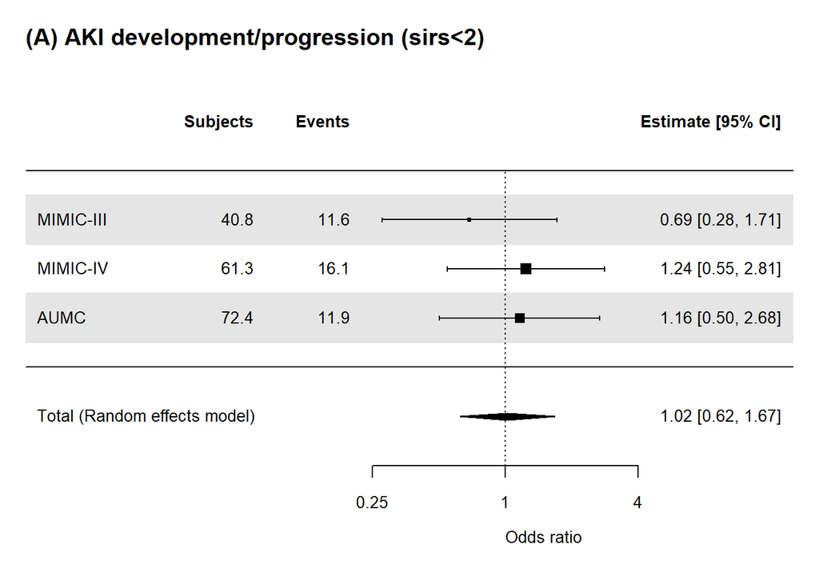

```r
FP2("wgt_man_Ovlp_MIMIC3_Lsirs.rds", FORMULA_ovl2_sirs)
FP2("wgt_man_Ovlp_MIMIC4_Lsirs.rds", FORMULA_ovl2_sirs)
FP2("wgt_man_Ovlp_AUMC_Lsirs.rds", FORMULA_ovl2_sirs)

Lsirs_METADF0 <- rbind(
  readRDS("ORRES_wgt_man_Ovlp_MIMIC3_Lsirs.rds") %>% mutate("dataset"="MIMIC-III"),
  readRDS("ORRES_wgt_man_Ovlp_MIMIC4_Lsirs.rds") %>% mutate("dataset"="MIMIC-IV"),
  readRDS("ORRES_wgt_man_Ovlp_AUMC_Lsirs.rds") %>% mutate("dataset"="AUMC"))
Lsirs_METADF_AKID <- Lsirs_METADF0 %>% subset(outcome=="outcome_KDIGO_inc_or_death")
Lsirs_METADF_AKI <- Lsirs_METADF0 %>% subset(outcome=="outcome_KDIGO_inc")
Lsirs_METADF_HD <- Lsirs_METADF0 %>% subset(outcome=="outcome_new_dial")
Lsirs_METADF_D <- Lsirs_METADF0 %>% subset(outcome=="death_in_7d")
Lsirs_METADF_HDD <- Lsirs_METADF0 %>% subset(outcome=="outcome_HDD_in7d")
Lsirs_METARES_AKID <- rma(yi = Estimate, sei = Std.Error, method = "REML", data = Lsirs_METADF_AKID)
Lsirs_METARES_AKI <- rma(yi = Estimate, sei = Std.Error, method = "REML", data = Lsirs_METADF_AKI)
Lsirs_METARES_HD <- rma(yi = Estimate, sei = Std.Error, method = "REML", data = Lsirs_METADF_HD)
Lsirs_METARES_D <- rma(yi = Estimate, sei = Std.Error, method = "REML", data = Lsirs_METADF_D)
Lsirs_METARES_HDD <- rma(yi = Estimate, sei = Std.Error, method = "REML", data = Lsirs_METADF_HDD)

METAF(Lsirs_METARES_AKI, SCALEA1, SCALEB1, SCALEC1, "(A) AKI development/progression (sirs<2)")
```

```r
Lsirs_METARES_AKI
```

```
##
## Random-Effects Model (k = 3; tau^2 estimator: REML)
##
## tau^2 (estimated amount of total heterogeneity): 0 (SE = 0.1893)
## tau (square root of estimated tau^2 value):      0
## I^2 (total heterogeneity / total variability):   0.00%
## H^2 (total variability / sampling variability):  1.00
##
## Test for Heterogeneity:
## Q(df = 2) = 1.0254, p-val = 0.5989
##
## Model Results:
##
## estimate      se    zval    pval    ci.lb   ci.ub
##   0.0209  0.2510  0.0833  0.9336  -0.4710  0.5129
##
## ---
## Signif. codes:  0 '***' 0.001 '**' 0.01 '*' 0.05 '.' 0.1 ' ' 1
```

```r
Lsirs_METADF_AKI %>% dplyr::select(dataset, OR, LCI, UCI, 'Pr(>|z|)') %>% remove_rownames()
```

```
##     dataset        OR       LCI      UCI  Pr(>|z|)
## 1 MIMIC-III 0.6896311 0.2779106 1.711310 0.4229249
## 2  MIMIC-IV 1.2406047 0.5469111 2.814169 0.6059166
## 3      AUMC 1.1620638 0.5036833 2.681035 0.7247414
```

__

__

#### 10d. Backgrounds, outcomes, matching quality, and forest plot among those **SIRS>1.99**

```r
#1. overlap-PSM using MIMIC3, SIRS>1.99
OVLP(comb_DF2ovl %>% subset(dataset=="MIMIC3"&sirs>1.99), FORMULA_ovl2_sirs, "Ovlp_MIMIC3_Hsirs", "**Ovlp, MIMIC-III, SIRS>1.99**")
```

| **Characteristic** | **Ovlp, MIMIC-III, SIRS>1.99** **I/C** N=39.1<sup>1</sup> | **Ovlp, MIMIC-III, SIRS>1.99** **NCC** N=39.1<sup>1</sup> | **p-value**<sup>2</sup> |  |
| --- | --- | --- | --- | --- |
| dataset |  |  |  |  |
| MIMIC3 | 39.1 (100.0%) | 39.1 (100.0%) |  |  |
| age_group |  |  | >0.99 |  |
| 18-39 | 2.5 (6.3%) | 2.7 (6.9%) |  |  |
| 40-49 | 4.7 (12.0%) | 4.3 (10.9%) |  |  |
| 50-59 | 7.3 (18.7%) | 6.6 (16.9%) |  |  |
| 60-69 | 8.8 (22.4%) | 9.4 (24.1%) |  |  |
| 70-79 | 9.0 (22.9%) | 10.0 (25.5%) |  |  |
| 80+ | 7.0 (17.8%) | 6.1 (15.7%) |  |  |
| sex |  |  | >0.99 |  |
| Female | 19.2 (49.1%) | 19.2 (49.1%) |  |  |
| Male | 19.9 (50.9%) | 19.9 (50.9%) |  |  |
| bmi | 27.7 (24.9, 30.6) | 27.8 (23.8, 34.9) | 0.88 |  |
| Unknown | 18 | 20 |  |  |
| ICU type |  |  | >0.99 |  |
| Non-surgery | 22.8 (58.3%) | 22.8 (58.3%) |  |  |
| Surgery | 16.3 (41.7%) | 16.3 (41.7%) |  |  |
| drug_name |  |  |  |  |
| Imipenem/cilastatin | 39.1 (100.0%) | 0.0 (0.0%) |  |  |
| Imipenem/cilastatin/relebactam | 0.0 (0.0%) | 0.0 (0.0%) |  |  |
| Meropenem | 0.0 (0.0%) | 39.1 (100.0%) |  |  |
| Doripenem | 0.0 (0.0%) | 0.0 (0.0%) |  |  |
| Ertapenem | 0.0 (0.0%) | 0.0 (0.0%) |  |  |
| sofa | 5.0 (3.0, 9.0) | 4.0 (2.0, 7.0) | 0.21 |  |
| qsofa | 1.0 (0.0, 1.0) | 1.0 (0.0, 1.0) | 0.71 |  |
| sirs | 3.0 (2.0, 3.0) | 2.0 (2.0, 3.0) | 0.60 |  |
| pre_blood_culture | 32.5 (83.0%) | 32.5 (83.0%) | >0.99 |  |
| pre vancomycin use | 11.2 (28.6%) | 11.2 (28.6%) | >0.99 |  |
| pre vasopressor use | 17.9 (45.7%) | 17.9 (45.7%) | >0.99 |  |
| pre ventilation | 27.4 (70.1%) | 26.7 (68.2%) | 0.79 |  |
| Baseline sCr | 0.8 (0.6, 1.2) | 0.9 (0.6, 1.3) | 0.76 |  |
| sCr at treatment start | 1.1 (0.8, 1.5) | 1.0 (0.7, 1.6) | 0.87 |  |
| AKI stage at treatment start |  |  | 0.95 |  |
| 0 | 27.5 (70.3%) | 27.8 (71.1%) |  |  |
| 1 | 10.2 (26.0%) | 9.6 (24.5%) |  |  |
| 2 | 1.4 (3.6%) | 1.7 (4.4%) |  |  |
| observation time | 168.0 (168.0, 168.0) | 168.0 (168.0, 168.0) | 0.37 |  |
| Cencsored with drug change | 1.6 (4.0%) | 0.0 (0.0%) | 0.15 |  |
| RRT at treatment start | 0.0 (0.0%) | 0.0 (0.0%) |  |  |
| O, AKI develop/progress | 9.8 (25.0%) | 16.5 (42.2%) | 0.031 |  |
| O, Death | 6.1 (15.6%) | 6.2 (15.9%) | 0.96 |  |
| O, AKI d/p or death | 12.8 (32.7%) | 18.4 (46.9%) | 0.077 |  |
| O, RRT-intervention | 1.5 (3.8%) | 2.0 (5.0%) | 0.71 |  |
| O, Death or RRT-intervention | 6.9 (17.7%) | 7.8 (19.8%) | 0.74 |  |

<sup>1</sup> n (%); Median (Q1, Q3)  
<sup>2</sup> NA; Pearson’s X^2: Rao & Scott adjustment; Design-based KruskalWallis test

```r
#2. overlap-PSM using MIMIC4, SIRS>1.99
OVLP(comb_DF2ovl %>% subset(dataset=="miiv"&sirs>1.99), FORMULA_ovl2_sirs, "Ovlp_MIMIC4_Hsirs", "**Ovlp, MIMIC-IV, SIRS>1.99**")
```

| **Characteristic** | **Ovlp, MIMIC-IV, SIRS>1.99** **I/C** N=53.9<sup>1</sup> | **Ovlp, MIMIC-IV, SIRS>1.99** **NCC** N=53.9<sup>1</sup> | **p-value**<sup>2</sup> |  |
| --- | --- | --- | --- | --- |
| dataset |  |  |  |  |
| miiv | 53.9 (100.0%) | 53.9 (100.0%) |  |  |
| age_group |  |  | 0.48 |  |
| 18-39 | 6.8 (12.6%) | 5.0 (9.2%) |  |  |
| 40-49 | 5.8 (10.8%) | 5.7 (10.6%) |  |  |
| 50-59 | 5.8 (10.7%) | 11.2 (20.7%) |  |  |
| 60-69 | 16.4 (30.4%) | 14.2 (26.4%) |  |  |
| 70-79 | 11.5 (21.4%) | 10.0 (18.6%) |  |  |
| 80+ | 7.6 (14.1%) | 7.8 (14.5%) |  |  |
| sex |  |  | >0.99 |  |
| Female | 23.1 (42.9%) | 23.1 (42.9%) |  |  |
| Male | 30.7 (57.1%) | 30.7 (57.1%) |  |  |
| bmi | 26.4 (24.7, 31.6) | 27.2 (23.3, 32.9) | 0.91 |  |
| Unknown | 31 | 18 |  |  |
| ICU type |  |  | >0.99 |  |
| Non-surgery | 48.0 (89.0%) | 48.0 (89.0%) |  |  |
| Surgery | 5.9 (11.0%) | 5.9 (11.0%) |  |  |
| drug_name |  |  | <0.001 |  |
| Imipenem/cilastatin | 52.9 (98.2%) | 0.0 (0.0%) |  |  |
| Imipenem/cilastatin/relebactam | 1.0 (1.8%) | 0.0 (0.0%) |  |  |
| Meropenem | 0.0 (0.0%) | 53.5 (99.3%) |  |  |
| Doripenem | 0.0 (0.0%) | 0.2 (0.4%) |  |  |
| Ertapenem | 0.0 (0.0%) | 0.2 (0.3%) |  |  |
| sofa | 5.0 (3.0, 8.0) | 6.0 (3.0, 9.0) | 0.19 |  |
| qsofa | 1.0 (1.0, 1.0) | 1.0 (1.0, 2.0) | 0.37 |  |
| sirs | 2.0 (2.0, 3.0) | 2.0 (2.0, 3.0) | 0.53 |  |
| pre_blood_culture | 47.0 (87.3%) | 47.0 (87.3%) | >0.99 |  |
| pre vancomycin use | 35.7 (66.3%) | 35.7 (66.3%) | >0.99 |  |
| pre vasopressor use | 6.7 (12.4%) | 6.7 (12.4%) | >0.99 |  |
| pre ventilation | 9.6 (17.8%) | 5.9 (11.0%) | 0.12 |  |
| Baseline sCr | 0.9 (0.6, 1.5) | 0.9 (0.6, 1.4) | 0.92 |  |
| sCr at treatment start | 1.0 (0.6, 2.0) | 1.1 (0.7, 1.7) | 0.90 |  |
| AKI stage at treatment start |  |  | 0.91 |  |
| 0 | 42.2 (78.4%) | 41.8 (77.5%) |  |  |
| 1 | 8.7 (16.2%) | 9.7 (17.9%) |  |  |
| 2 | 2.9 (5.4%) | 2.4 (4.5%) |  |  |
| observation time | 168.0 (101.0, 168.0) | 168.0 (145.8, 168.0) | 0.26 |  |
| Unknown | 7 | 5 |  |  |
| Cencsored with drug change | 2.0 (3.6%) | 0.0 (0.0%) | 0.15 |  |
| RRT at treatment start | 0.0 (0.0%) | 0.0 (0.0%) |  |  |
| O, AKI develop/progress | 22.0 (40.9%) | 19.9 (37.0%) | 0.56 |  |
| O, Death | 10.5 (19.6%) | 10.3 (19.1%) | 0.93 |  |
| O, AKI d/p or death | 22.9 (42.6%) | 23.7 (43.9%) | 0.84 |  |
| O, RRT-intervention | 2.9 (5.4%) | 4.3 (8.0%) | 0.47 |  |
| O, Death or RRT-intervention | 11.5 (21.4%) | 13.0 (24.1%) | 0.63 |  |

<sup>1</sup> n (%); Median (Q1, Q3)  
<sup>2</sup> NA; Pearson’s X^2: Rao & Scott adjustment; Design-based KruskalWallis test

```r
#3. overlap-PSM using AUMC, SIRS>1.99
OVLP(comb_DF2ovl %>% subset(dataset=="AUMC"&sirs>1.99), FORMULA_ovl2_sirs, "Ovlp_AUMC_Hsirs", "**Ovlp, AUMC, SIRS>1.99**")
```

| **Characteristic** | **Ovlp, AUMC, SIRS>1.99** **I/C** N=105.0<sup>1</sup> | **Ovlp, AUMC, SIRS>1.99** **NCC** N=105.0<sup>1</sup> | **p-value**<sup>2</sup> |  |
| --- | --- | --- | --- | --- |
| dataset |  |  |  |  |
| AUMC | 105.0 (100.0%) | 105.0 (100.0%) |  |  |
| age_group |  |  | 0.34 |  |
| 18-39 | 11.2 (10.7%) | 15.6 (14.9%) |  |  |
| 40-49 | 11.8 (11.3%) | 11.2 (10.7%) |  |  |
| 50-59 | 23.9 (22.7%) | 18.1 (17.3%) |  |  |
| 60-69 | 32.1 (30.5%) | 27.8 (26.5%) |  |  |
| 70-79 | 22.9 (21.9%) | 26.8 (25.6%) |  |  |
| 80+ | 3.1 (3.0%) | 5.4 (5.2%) |  |  |
| sex |  |  | >0.99 |  |
| Female | 41.3 (39.4%) | 41.3 (39.4%) |  |  |
| Male | 63.6 (60.6%) | 63.6 (60.6%) |  |  |
| bmi | 24.5 (21.9, 27.8) | 24.5 (21.3, 27.8) | 0.94 |  |
| Unknown | 5 | 3 |  |  |
| ICU type |  |  | >0.99 |  |
| Non-surgery | 60.3 (57.5%) | 60.3 (57.5%) |  |  |
| Surgery | 44.7 (42.5%) | 44.7 (42.5%) |  |  |
| drug_name |  |  |  |  |
| Imipenem/cilastatin | 105.0 (100.0%) | 0.0 (0.0%) |  |  |
| Imipenem/cilastatin/relebactam | 0.0 (0.0%) | 0.0 (0.0%) |  |  |
| Meropenem | 0.0 (0.0%) | 105.0 (100.0%) |  |  |
| Doripenem | 0.0 (0.0%) | 0.0 (0.0%) |  |  |
| Ertapenem | 0.0 (0.0%) | 0.0 (0.0%) |  |  |
| sofa | 8.0 (5.0, 10.0) | 8.0 (4.0, 10.0) | 0.66 |  |
| Unknown | 15 | 20 |  |  |
| qsofa | 1.0 (0.0, 1.0) | 1.0 (0.0, 1.0) | 0.85 |  |
| Unknown | 0 | 0 |  |  |
| sirs | 2.0 (2.0, 3.0) | 3.0 (2.0, 3.0) | 0.37 |  |
| pre_blood_culture | 17.3 (16.5%) | 17.3 (16.5%) | >0.99 |  |
| pre vancomycin use | 52.7 (50.2%) | 52.7 (50.2%) | >0.99 |  |
| pre vasopressor use | 67.7 (64.5%) | 67.7 (64.5%) | >0.99 |  |
| pre ventilation | 69.0 (65.7%) | 60.9 (58.0%) | 0.10 |  |
| Baseline sCr | 0.8 (0.6, 1.2) | 0.8 (0.6, 1.2) | 0.43 |  |
| sCr at treatment start | 1.0 (0.7, 1.5) | 1.0 (0.6, 1.6) | 0.43 |  |
| AKI stage at treatment start |  |  | >0.99 |  |
| 0 | 73.0 (69.6%) | 73.3 (69.8%) |  |  |
| 1 | 24.1 (22.9%) | 23.7 (22.5%) |  |  |
| 2 | 7.8 (7.5%) | 8.1 (7.7%) |  |  |
| observation time | 168.0 (64.0, 168.0) | 146.0 (61.0, 168.0) | 0.46 |  |
| Cencsored with drug change | 3.2 (3.0%) | 1.4 (1.4%) | 0.30 |  |
| RRT at treatment start | 0.0 (0.0%) | 0.0 (0.0%) |  |  |
| O, AKI develop/progress | 35.8 (34.1%) | 34.4 (32.8%) | 0.77 |  |
| O, Death | 17.0 (16.2%) | 17.0 (16.2%) | >0.99 |  |
| O, AKI d/p or death | 41.0 (39.1%) | 42.8 (40.7%) | 0.73 |  |
| O, RRT-intervention | 12.3 (11.7%) | 13.8 (13.2%) | 0.65 |  |
| O, Death or RRT-intervention | 24.3 (23.2%) | 24.9 (23.7%) | 0.90 |  |

<sup>1</sup> n (%); Median (Q1, Q3)  
<sup>2</sup> NA; Pearson’s X^2: Rao & Scott adjustment; Design-based KruskalWallis test

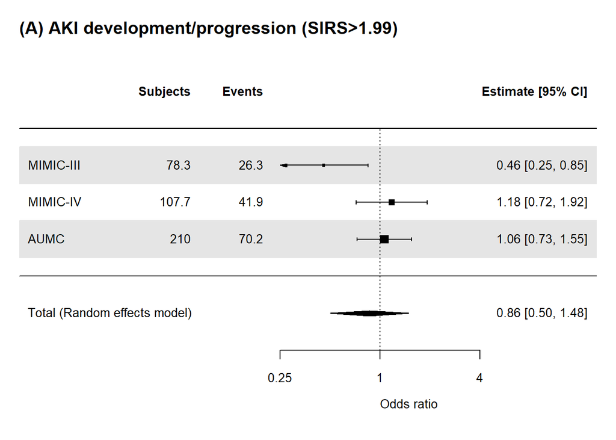

```r
FP2("wgt_man_Ovlp_MIMIC4_Hsirs.rds", FORMULA_ovl2_sirs)
FP2("wgt_man_Ovlp_MIMIC3_Hsirs.rds", FORMULA_ovl2_sirs)
FP2("wgt_man_Ovlp_AUMC_Hsirs.rds", FORMULA_ovl2_sirs)

Hsirs_METADF0 <- rbind(
  readRDS("ORRES_wgt_man_Ovlp_MIMIC3_Hsirs.rds") %>% mutate("dataset"="MIMIC-III"),
  readRDS("ORRES_wgt_man_Ovlp_MIMIC4_Hsirs.rds") %>% mutate("dataset"="MIMIC-IV"),
  readRDS("ORRES_wgt_man_Ovlp_AUMC_Hsirs.rds") %>% mutate("dataset"="AUMC"))
Hsirs_METADF_AKID <- Hsirs_METADF0 %>% subset(outcome=="outcome_KDIGO_inc_or_death")
Hsirs_METADF_AKI <- Hsirs_METADF0 %>% subset(outcome=="outcome_KDIGO_inc")
Hsirs_METADF_HD <- Hsirs_METADF0 %>% subset(outcome=="outcome_new_dial")
Hsirs_METADF_D <- Hsirs_METADF0 %>% subset(outcome=="death_in_7d")
Hsirs_METADF_HDD <- Hsirs_METADF0 %>% subset(outcome=="outcome_HDD_in7d")

Hsirs_METARES_AKID <- rma(yi = Estimate, sei = Std.Error, method = "REML", data = Hsirs_METADF_AKID)
Hsirs_METARES_AKI <-rma(yi = Estimate, sei = Std.Error, method = "REML", data = Hsirs_METADF_AKI)
Hsirs_METARES_HD <- rma(yi = Estimate, sei = Std.Error, method = "REML", data = Hsirs_METADF_HD)
Hsirs_METARES_D <- rma(yi = Estimate, sei = Std.Error, method = "REML", data = Hsirs_METADF_D)
Hsirs_METARES_HDD <- rma(yi = Estimate, sei = Std.Error, method = "REML", data = Hsirs_METADF_HDD)

METAF(Hsirs_METARES_AKI, SCALEA1, SCALEB1, SCALEC1, "(A) AKI development/progression (SIRS>1.99)")
```

```r
Hsirs_METARES_AKI
```

```
##
## Random-Effects Model (k = 3; tau^2 estimator: REML)
##
## tau^2 (estimated amount of total heterogeneity): 0.1637 (SE = 0.2284)
## tau (square root of estimated tau^2 value):      0.4046
## I^2 (total heterogeneity / total variability):   72.59%
## H^2 (total variability / sampling variability):  3.65
##
## Test for Heterogeneity:
## Q(df = 2) = 6.3761, p-val = 0.0413
##
## Model Results:
##
## estimate      se     zval    pval    ci.lb   ci.ub
##  -0.1478  0.2755  -0.5365  0.5916  -0.6878  0.3922
##
## ---
## Signif. codes:  0 '***' 0.001 '**' 0.01 '*' 0.05 '.' 0.1 ' ' 1
```

```r
Hsirs_METADF_AKI %>% dplyr::select(dataset, OR, LCI, UCI, 'Pr(>|z|)') %>% remove_rownames()
```

```
##     dataset       OR       LCI       UCI   Pr(>|z|)
## 1 MIMIC-III 0.457005 0.2455408 0.8505862 0.01349128
## 2  MIMIC-IV 1.176235 0.7202198 1.9209807 0.51661172
## 3      AUMC 1.062111 0.7269933 1.5517054 0.75538929
```

__

#### 11c. Backgrounds, outcomes, matching quality, and forrest plot among those **with vasopressor** at treatment start.

```r
FORMULA_ovl2_vaso <- drug01 ~  age_cat + sex + dep_type2 + sirs + pre_blood_culture + treat_van + base_crea + near_crea +  base_KDIGO

#1. overlap-PSM using MIMIC3, vasopressor
OVLP(comb_DF2ovl %>% subset(dataset=="MIMIC3"&vasopressor==T), FORMULA_ovl2_vaso, "Ovlp_MIMIC3_vaso", "**Ovlp, MIMIC-III, with vaso**")
```

| **Characteristic** | **Ovlp, MIMIC-III, with vaso** **I/C** N=23.6<sup>1</sup> | **Ovlp, MIMIC-III, with vaso** **NCC** N=23.6<sup>1</sup> | **p-value**<sup>2</sup> |  |
| --- | --- | --- | --- | --- |
| dataset |  |  |  |  |
| MIMIC3 | 23.6 (100.0%) | 23.6 (100.0%) |  |  |
| age_group |  |  | 0.90 |  |
| 18-39 | 0.8 (3.5%) | 1.6 (6.7%) |  |  |
| 40-49 | 2.4 (10.3%) | 1.7 (7.1%) |  |  |
| 50-59 | 4.2 (17.7%) | 3.2 (13.6%) |  |  |
| 60-69 | 4.7 (19.7%) | 4.6 (19.5%) |  |  |
| 70-79 | 7.0 (29.6%) | 8.8 (37.3%) |  |  |
| 80+ | 4.5 (19.2%) | 3.7 (15.8%) |  |  |
| sex |  |  | >0.99 |  |
| Female | 11.6 (49.2%) | 11.6 (49.2%) |  |  |
| Male | 12.0 (50.8%) | 12.0 (50.8%) |  |  |
| bmi | 26.3 (25.4, 29.7) | 27.6 (23.4, 32.9) | 0.81 |  |
| Unknown | 6 | 9 |  |  |
| ICU type |  |  | >0.99 |  |
| Non-surgery | 13.9 (58.9%) | 13.9 (58.9%) |  |  |
| Surgery | 9.7 (41.1%) | 9.7 (41.1%) |  |  |
| drug_name |  |  |  |  |
| Imipenem/cilastatin | 23.6 (100.0%) | 0.0 (0.0%) |  |  |
| Imipenem/cilastatin/relebactam | 0.0 (0.0%) | 0.0 (0.0%) |  |  |
| Meropenem | 0.0 (0.0%) | 23.6 (100.0%) |  |  |
| Doripenem | 0.0 (0.0%) | 0.0 (0.0%) |  |  |
| Ertapenem | 0.0 (0.0%) | 0.0 (0.0%) |  |  |
| sofa | 8.0 (6.0, 10.0) | 7.0 (4.0, 10.0) | 0.23 |  |
| qsofa | 1.0 (1.0, 1.0) | 1.0 (0.0, 1.0) | 0.27 |  |
| sirs | 2.0 (1.0, 3.0) | 2.0 (1.0, 3.0) | 0.86 |  |
| pre_blood_culture | 21.9 (93.0%) | 21.9 (93.0%) | >0.99 |  |
| pre vancomycin use | 9.6 (40.8%) | 9.6 (40.8%) | >0.99 |  |
| pre vasopressor use | 23.6 (100.0%) | 23.6 (100.0%) |  |  |
| pre ventilation | 17.2 (73.1%) | 18.7 (79.0%) | 0.49 |  |
| Baseline sCr | 0.9 (0.6, 1.4) | 1.0 (0.7, 1.8) | 0.68 |  |
| sCr at treatment start | 1.1 (0.8, 1.8) | 1.2 (0.8, 2.0) | 0.88 |  |
| AKI stage at treatment start |  |  | 0.70 |  |
| 0 | 18.6 (78.6%) | 18.1 (76.5%) |  |  |
| 1 | 4.1 (17.5%) | 5.1 (21.7%) |  |  |
| 2 | 0.9 (3.8%) | 0.4 (1.7%) |  |  |
| observation time | 168.0 (168.0, 168.0) | 168.0 (168.0, 168.0) | 0.67 |  |
| Cencsored with drug change | 0.8 (3.5%) | 0.2 (0.7%) | 0.20 |  |
| RRT at treatment start | 0.0 (0.0%) | 0.0 (0.0%) |  |  |
| O, AKI develop/progress | 7.5 (32.0%) | 12.8 (54.2%) | 0.033 |  |
| O, Death | 4.0 (17.0%) | 5.3 (22.5%) | 0.53 |  |
| O, AKI d/p or death | 9.2 (39.1%) | 13.9 (59.0%) | 0.055 |  |
| O, RRT-intervention | 1.7 (7.1%) | 1.9 (8.2%) | 0.84 |  |
| O, Death or RRT-intervention | 4.8 (20.5%) | 6.5 (27.5%) | 0.45 |  |

<sup>1</sup> n (%); Median (Q1, Q3)  
<sup>2</sup> NA; Pearson’s X^2: Rao & Scott adjustment; Design-based KruskalWallis test

```r
#2. overlap-PSM using MIMIC4, vasopressor
OVLP(comb_DF2ovl %>% subset(dataset=="miiv"&vasopressor==T), FORMULA_ovl2_vaso, "Ovlp_MIMIC4_vaso", "**Ovlp, MIMIC-IV, with vaso**")
```

| **Characteristic** | **Ovlp, MIMIC-IV, with vaso** **I/C** N=7.4<sup>1</sup> | **Ovlp, MIMIC-IV, with vaso** **NCC** N=7.4<sup>1</sup> | **p-value**<sup>2</sup> |  |
| --- | --- | --- | --- | --- |
| dataset |  |  |  |  |
| miiv | 7.4 (100.0%) | 7.4 (100.0%) |  |  |
| age_group |  |  | 0.30 |  |
| 18-39 | 0.0 (0.0%) | 0.1 (1.3%) |  |  |
| 40-49 | 1.0 (13.2%) | 0.3 (4.4%) |  |  |
| 50-59 | 0.0 (0.0%) | 1.2 (15.7%) |  |  |
| 60-69 | 2.7 (36.8%) | 2.0 (26.6%) |  |  |
| 70-79 | 1.9 (26.0%) | 2.0 (27.6%) |  |  |
| 80+ | 1.8 (24.0%) | 1.8 (24.4%) |  |  |
| sex |  |  | >0.99 |  |
| Female | 3.7 (49.9%) | 3.7 (49.9%) |  |  |
| Male | 3.7 (50.1%) | 3.7 (50.1%) |  |  |
| bmi | 28.6 (24.8, 33.6) | 26.3 (22.3, 33.8) | 0.51 |  |
| Unknown | 5 | 2 |  |  |
| ICU type |  |  | 0.002 |  |
| Non-surgery | 7.4 (100.0%) | 7.4 (100.0%) |  |  |
| Surgery | 0.0 (0.0%) | 0.0 (0.0%) |  |  |
| drug_name |  |  |  |  |
| Imipenem/cilastatin | 7.4 (100.0%) | 0.0 (0.0%) |  |  |
| Imipenem/cilastatin/relebactam | 0.0 (0.0%) | 0.0 (0.0%) |  |  |
| Meropenem | 0.0 (0.0%) | 7.4 (100.0%) |  |  |
| Doripenem | 0.0 (0.0%) | 0.0 (0.0%) |  |  |
| Ertapenem | 0.0 (0.0%) | 0.0 (0.0%) |  |  |
| sofa | 12.0 (8.0, 13.0) | 10.0 (7.0, 12.0) | 0.29 |  |
| qsofa | 1.0 (0.0, 2.0) | 1.0 (1.0, 2.0) | 0.85 |  |
| sirs | 3.0 (2.0, 3.0) | 3.0 (2.0, 3.0) | >0.99 |  |
| pre_blood_culture | 7.4 (100.0%) | 7.4 (100.0%) | 0.014 |  |
| pre vancomycin use | 4.8 (64.6%) | 4.8 (64.6%) | >0.99 |  |
| pre vasopressor use | 7.4 (100.0%) | 7.4 (100.0%) |  |  |
| pre ventilation | 7.4 (100.0%) | 5.6 (76.7%) | <0.001 |  |
| Baseline sCr | 1.0 (0.7, 1.3) | 0.9 (0.6, 1.3) | 0.69 |  |
| sCr at treatment start | 1.5 (0.7, 1.9) | 1.5 (0.8, 2.0) | 0.94 |  |
| AKI stage at treatment start |  |  | >0.99 |  |
| 0 | 3.7 (50.1%) | 3.6 (49.6%) |  |  |
| 1 | 1.9 (26.1%) | 2.0 (27.0%) |  |  |
| 2 | 1.8 (23.9%) | 1.7 (23.4%) |  |  |
| observation time | 62.9 (22.5, 168.0) | 101.0 (49.9, 168.0) | 0.33 |  |
| Unknown | 0 | 1 |  |  |
| Cencsored with drug change | 0.0 (0.0%) | 0.0 (0.0%) |  |  |
| RRT at treatment start | 0.0 (0.0%) | 0.0 (0.0%) |  |  |
| O, AKI develop/progress | 6.4 (87.0%) | 4.7 (64.4%) | 0.22 |  |
| O, Death | 7.4 (100.0%) | 7.4 (100.0%) |  |  |
| O, AKI d/p or death | 7.4 (100.0%) | 7.4 (100.0%) |  |  |
| O, RRT-intervention | 1.8 (23.9%) | 1.2 (16.2%) | 0.58 |  |
| O, Death or RRT-intervention | 7.4 (100.0%) | 7.4 (100.0%) |  |  |

<sup>1</sup> n (%); Median (Q1, Q3)  
<sup>2</sup> NA; Pearson’s X^2: Rao & Scott adjustment; Design-based KruskalWallis test

```r
#3. overlap-PSM using AUMC, vasopressor
OVLP(comb_DF2ovl %>% subset(dataset=="AUMC"&vasopressor==T), FORMULA_ovl2_vaso, "Ovlp_AUMC_vaso", paste0("**Ovlp, AUMC, with vaso**"))
```

| **Characteristic** | **Ovlp, AUMC, with vaso** **I/C** N=90.4<sup>1</sup> | **Ovlp, AUMC, with vaso** **NCC** N=90.4<sup>1</sup> | **p-value**<sup>2</sup> |  |
| --- | --- | --- | --- | --- |
| dataset |  |  |  |  |
| AUMC | 90.4 (100.0%) | 90.4 (100.0%) |  |  |
| age_group |  |  | 0.86 |  |
| 18-39 | 7.8 (8.6%) | 9.9 (10.9%) |  |  |
| 40-49 | 9.2 (10.2%) | 8.7 (9.6%) |  |  |
| 50-59 | 19.3 (21.3%) | 15.5 (17.2%) |  |  |
| 60-69 | 25.9 (28.6%) | 27.2 (30.1%) |  |  |
| 70-79 | 24.3 (26.9%) | 23.7 (26.2%) |  |  |
| 80+ | 3.9 (4.3%) | 5.5 (6.0%) |  |  |
| sex |  |  | >0.99 |  |
| Female | 29.5 (32.6%) | 29.5 (32.6%) |  |  |
| Male | 60.9 (67.4%) | 60.9 (67.4%) |  |  |
| bmi | 24.5 (21.9, 27.8) | 24.5 (21.9, 27.8) | 0.75 |  |
| Unknown | 2 | 0 |  |  |
| ICU type |  |  | >0.99 |  |
| Non-surgery | 56.6 (62.6%) | 56.6 (62.6%) |  |  |
| Surgery | 33.8 (37.4%) | 33.8 (37.4%) |  |  |
| drug_name |  |  |  |  |
| Imipenem/cilastatin | 90.4 (100.0%) | 0.0 (0.0%) |  |  |
| Imipenem/cilastatin/relebactam | 0.0 (0.0%) | 0.0 (0.0%) |  |  |
| Meropenem | 0.0 (0.0%) | 90.4 (100.0%) |  |  |
| Doripenem | 0.0 (0.0%) | 0.0 (0.0%) |  |  |
| Ertapenem | 0.0 (0.0%) | 0.0 (0.0%) |  |  |
| sofa | 8.0 (7.0, 10.0) | 8.0 (6.0, 11.0) | 0.71 |  |
| Unknown | 13 | 17 |  |  |
| qsofa | 1.0 (0.0, 1.0) | 1.0 (0.0, 1.0) | 0.84 |  |
| sirs | 2.0 (2.0, 3.0) | 2.0 (1.0, 3.0) | 0.97 |  |
| pre_blood_culture | 13.5 (14.9%) | 13.5 (14.9%) | >0.99 |  |
| pre vancomycin use | 46.6 (51.5%) | 46.6 (51.5%) | >0.99 |  |
| pre vasopressor use | 90.4 (100.0%) | 90.4 (100.0%) |  |  |
| pre ventilation | 75.2 (83.2%) | 67.3 (74.5%) | 0.038 |  |
| Baseline sCr | 0.8 (0.6, 1.2) | 0.8 (0.6, 1.1) | 0.77 |  |
| sCr at treatment start | 1.0 (0.7, 1.5) | 1.0 (0.7, 1.5) | 0.76 |  |
| AKI stage at treatment start |  |  | 0.73 |  |
| 0 | 63.7 (70.4%) | 64.9 (71.8%) |  |  |
| 1 | 21.4 (23.7%) | 18.8 (20.8%) |  |  |
| 2 | 5.3 (5.9%) | 6.6 (7.3%) |  |  |
| observation time | 168.0 (88.5, 168.0) | 162.0 (67.0, 168.0) | 0.048 |  |
| Cencsored with drug change | 1.9 (2.1%) | 0.8 (0.9%) | 0.40 |  |
| RRT at treatment start | 0.0 (0.0%) | 0.0 (0.0%) |  |  |
| O, AKI develop/progress | 29.9 (33.1%) | 28.4 (31.5%) | 0.74 |  |
| O, Death | 13.4 (14.8%) | 15.3 (16.9%) | 0.58 |  |
| O, AKI d/p or death | 34.5 (38.1%) | 36.1 (39.9%) | 0.72 |  |
| O, RRT-intervention | 8.8 (9.7%) | 10.0 (11.1%) | 0.67 |  |
| O, Death or RRT-intervention | 19.5 (21.6%) | 20.3 (22.5%) | 0.83 |  |

<sup>1</sup> n (%); Median (Q1, Q3)  
<sup>2</sup> NA; Pearson’s X^2: Rao & Scott adjustment; Design-based KruskalWallis test

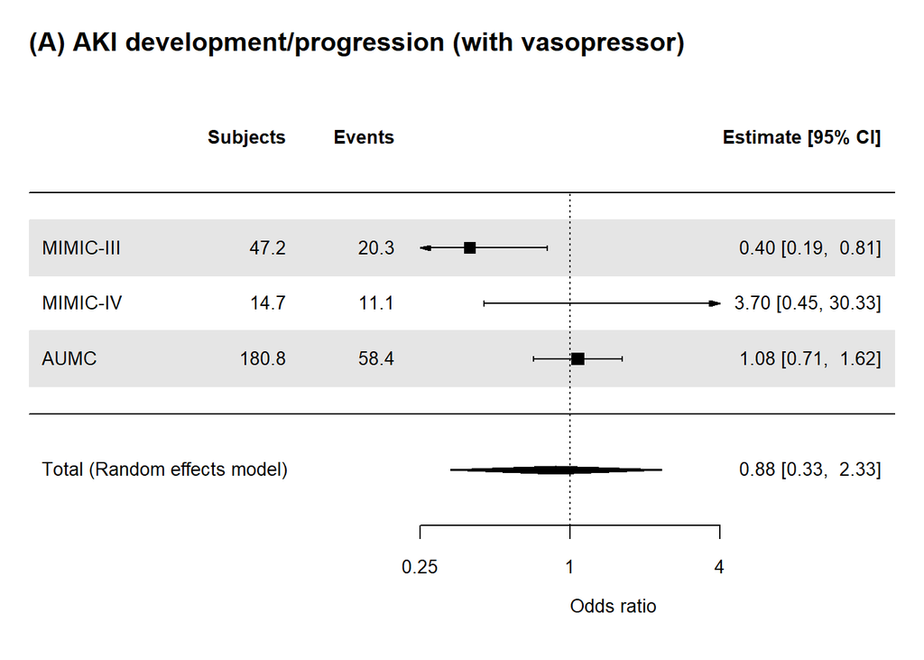

```r
#Forrestplot
FP2("wgt_man_Ovlp_MIMIC3_vaso.rds", FORMULA_ovl2_vaso)
FP2("wgt_man_Ovlp_MIMIC4_vaso.rds", FORMULA_ovl2_vaso)
FP2("wgt_man_Ovlp_AUMC_vaso.rds", FORMULA_ovl2_vaso)

vaso_METADF0 <- rbind(
  readRDS("ORRES_wgt_man_Ovlp_MIMIC3_vaso.rds") %>% mutate("dataset"="MIMIC-III"),
  readRDS("ORRES_wgt_man_Ovlp_MIMIC4_vaso.rds") %>% mutate("dataset"="MIMIC-IV"),
  readRDS("ORRES_wgt_man_Ovlp_AUMC_vaso.rds") %>% mutate("dataset"="AUMC"))
vaso_METADF_AKID <- vaso_METADF0 %>% subset(outcome=="outcome_KDIGO_inc_or_death")
vaso_METADF_AKI <- vaso_METADF0 %>% subset(outcome=="outcome_KDIGO_inc")
vaso_METADF_HD <- vaso_METADF0 %>% subset(outcome=="outcome_new_dial")
vaso_METADF_D <- vaso_METADF0 %>% subset(outcome=="death_in_7d")
vaso_METADF_HDD <- vaso_METADF0 %>% subset(outcome=="outcome_HDD_in7d")
vaso_METARES_AKID <- rma(yi = Estimate, sei = Std.Error, method = "REML", data = vaso_METADF_AKID)
vaso_METARES_AKI <- rma(yi = Estimate, sei = Std.Error, method = "REML", data = vaso_METADF_AKI)
vaso_METARES_HD <- rma(yi = Estimate, sei = Std.Error, method = "REML", data = vaso_METADF_HD)
vaso_METARES_D <- rma(yi = Estimate, sei = Std.Error, method = "REML", data = vaso_METADF_D)
vaso_METARES_HDD <- rma(yi = Estimate, sei = Std.Error, method = "REML", data = vaso_METADF_HDD)

METAF(vaso_METARES_AKI, SCALEA1, SCALEB1, SCALEC1, "(A) AKI development/progression (with vasopressor)")
```

```r
vaso_METARES_AKI
```

```
##
## Random-Effects Model (k = 3; tau^2 estimator: REML)
##
## tau^2 (estimated amount of total heterogeneity): 0.4978 (SE = 0.7550)
## tau (square root of estimated tau^2 value):      0.7056
## I^2 (total heterogeneity / total variability):   75.84%
## H^2 (total variability / sampling variability):  4.14
##
## Test for Heterogeneity:
## Q(df = 2) = 7.4490, p-val = 0.0241
##
## Model Results:
##
## estimate      se     zval    pval    ci.lb   ci.ub
##  -0.1318  0.4978  -0.2648  0.7911  -1.1076  0.8439
##
## ---
## Signif. codes:  0 '***' 0.001 '**' 0.01 '*' 0.05 '.' 0.1 ' ' 1
```

```r
vaso_METADF_AKI %>% dplyr::select(dataset, OR, LCI, UCI, 'Pr(>|z|)') %>% remove_rownames()
```

```
##     dataset        OR       LCI        UCI   Pr(>|z|)
## 1 MIMIC-III 0.3969912 0.1937288  0.8135186 0.01161016
## 2  MIMIC-IV 3.7006398 0.4515179 30.3304338 0.22279372
## 3      AUMC 1.0771143 0.7142136  1.6244094 0.72305989
```

__

__

#### 11d. Backgrounds, outcomes, matching quality, and forest plot among those **non-vasopressor**

```r
#1. overlap-PSM using MIMIC3, Older
OVLP(comb_DF2ovl %>% subset(dataset=="MIMIC3"&vasopressor==F), FORMULA_ovl2_vaso, "Ovlp_MIMIC3_nonvaso", "**Ovlp, MIMIC-III, No-vaso**")
```

| **Characteristic** | **Ovlp, MIMIC-III, No-vaso** **I/C** N=33.6<sup>1</sup> | **Ovlp, MIMIC-III, No-vaso** **NCC** N=33.6<sup>1</sup> | **p-value**<sup>2</sup> |  |
| --- | --- | --- | --- | --- |
| dataset |  |  |  |  |
| MIMIC3 | 33.6 (100.0%) | 33.6 (100.0%) |  |  |
| age_group |  |  | 0.89 |  |
| 18-39 | 2.6 (7.7%) | 3.4 (10.2%) |  |  |
| 40-49 | 3.9 (11.7%) | 3.6 (10.6%) |  |  |
| 50-59 | 6.4 (18.9%) | 5.8 (17.2%) |  |  |
| 60-69 | 8.4 (24.9%) | 6.4 (19.2%) |  |  |
| 70-79 | 5.8 (17.3%) | 8.2 (24.5%) |  |  |
| 80+ | 6.6 (19.5%) | 6.2 (18.3%) |  |  |
| sex |  |  | >0.99 |  |
| Female | 15.4 (46.0%) | 15.4 (46.0%) |  |  |
| Male | 18.1 (54.0%) | 18.1 (54.0%) |  |  |
| bmi | 28.7 (24.5, 31.6) | 28.5 (23.1, 33.8) | 0.81 |  |
| Unknown | 19 | 20 |  |  |
| ICU type |  |  | >0.99 |  |
| Non-surgery | 20.6 (61.4%) | 20.6 (61.4%) |  |  |
| Surgery | 13.0 (38.6%) | 13.0 (38.6%) |  |  |
| drug_name |  |  |  |  |
| Imipenem/cilastatin | 33.6 (100.0%) | 0.0 (0.0%) |  |  |
| Imipenem/cilastatin/relebactam | 0.0 (0.0%) | 0.0 (0.0%) |  |  |
| Meropenem | 0.0 (0.0%) | 33.6 (100.0%) |  |  |
| Doripenem | 0.0 (0.0%) | 0.0 (0.0%) |  |  |
| Ertapenem | 0.0 (0.0%) | 0.0 (0.0%) |  |  |
| sofa | 3.0 (2.0, 5.0) | 3.0 (1.0, 6.0) | 0.89 |  |
| qsofa | 0.0 (0.0, 1.0) | 1.0 (0.0, 1.0) | 0.26 |  |
| Unknown | 0 | 2 |  |  |
| sirs | 2.0 (1.0, 3.0) | 2.0 (1.0, 3.0) | 0.95 |  |
| pre_blood_culture | 24.3 (72.2%) | 24.3 (72.2%) | >0.99 |  |
| pre vancomycin use | 8.5 (25.3%) | 8.5 (25.3%) | >0.99 |  |
| pre vasopressor use | 0.0 (0.0%) | 0.0 (0.0%) |  |  |
| pre ventilation | 21.3 (63.4%) | 19.8 (59.0%) | 0.60 |  |
| Baseline sCr | 0.9 (0.6, 1.4) | 0.8 (0.6, 1.3) | 0.45 |  |
| sCr at treatment start | 1.1 (0.7, 1.7) | 1.0 (0.6, 1.5) | 0.46 |  |
| AKI stage at treatment start |  |  | 0.66 |  |
| 0 | 24.6 (73.4%) | 25.2 (75.1%) |  |  |
| 1 | 8.5 (25.4%) | 7.4 (22.0%) |  |  |
| 2 | 0.4 (1.2%) | 1.0 (2.9%) |  |  |
| observation time | 168.0 (145.0, 168.0) | 168.0 (168.0, 168.0) | 0.59 |  |
| Cencsored with drug change | 1.6 (4.8%) | 0.0 (0.0%) | 0.15 |  |
| RRT at treatment start | 0.0 (0.0%) | 0.0 (0.0%) |  |  |
| O, AKI develop/progress | 6.6 (19.7%) | 11.4 (34.1%) | 0.077 |  |
| O, Death | 3.1 (9.3%) | 4.3 (12.8%) | 0.51 |  |
| O, AKI d/p or death | 8.3 (24.7%) | 13.2 (39.3%) | 0.079 |  |
| O, RRT-intervention | 0.0 (0.0%) | 1.4 (4.3%) | 0.021 |  |
| O, Death or RRT-intervention | 3.1 (9.3%) | 5.6 (16.6%) | 0.22 |  |

<sup>1</sup> n (%); Median (Q1, Q3)  
<sup>2</sup> NA; Pearson’s X^2: Rao & Scott adjustment; Design-based KruskalWallis test

```r
#2. overlap-PSM using MIMIC4, Older
OVLP(comb_DF2ovl %>% subset(dataset=="miiv"&vasopressor==F), FORMULA_ovl2_vaso, "Ovlp_MIMIC4_nonvaso", "**Ovlp, MIMIC-IV, No-vaso**")
```

| **Characteristic** | **Ovlp, MIMIC-IV, No-vaso** **I/C** N=77.4<sup>1</sup> | **Ovlp, MIMIC-IV, No-vaso** **NCC** N=77.4<sup>1</sup> | **p-value**<sup>2</sup> |  |
| --- | --- | --- | --- | --- |
| dataset |  |  |  |  |
| miiv | 77.4 (100.0%) | 77.4 (100.0%) |  |  |
| age_group |  |  | 0.79 |  |
| 18-39 | 7.8 (10.1%) | 6.7 (8.7%) |  |  |
| 40-49 | 8.7 (11.3%) | 7.3 (9.4%) |  |  |
| 50-59 | 10.6 (13.8%) | 15.6 (20.1%) |  |  |
| 60-69 | 21.3 (27.5%) | 20.2 (26.1%) |  |  |
| 70-79 | 16.4 (21.2%) | 15.3 (19.7%) |  |  |
| 80+ | 12.5 (16.2%) | 12.3 (15.9%) |  |  |
| sex |  |  | >0.99 |  |
| Female | 32.9 (42.5%) | 32.9 (42.5%) |  |  |
| Male | 44.5 (57.5%) | 44.5 (57.5%) |  |  |
| bmi | 27.2 (25.1, 31.6) | 27.5 (23.7, 33.5) | 0.56 |  |
| Unknown | 38 | 30 |  |  |
| ICU type |  |  | >0.99 |  |
| Non-surgery | 62.8 (81.1%) | 62.8 (81.1%) |  |  |
| Surgery | 14.6 (18.9%) | 14.6 (18.9%) |  |  |
| drug_name |  |  | <0.001 |  |
| Imipenem/cilastatin | 76.4 (98.7%) | 0.0 (0.0%) |  |  |
| Imipenem/cilastatin/relebactam | 1.0 (1.3%) | 0.0 (0.0%) |  |  |
| Meropenem | 0.0 (0.0%) | 76.8 (99.2%) |  |  |
| Doripenem | 0.0 (0.0%) | 0.2 (0.2%) |  |  |
| Ertapenem | 0.0 (0.0%) | 0.4 (0.6%) |  |  |
| sofa | 4.0 (3.0, 6.0) | 5.0 (3.0, 8.0) | 0.15 |  |
| qsofa | 1.0 (0.0, 1.0) | 1.0 (0.0, 1.0) | 0.73 |  |
| Unknown | 0 | 0 |  |  |
| sirs | 2.0 (1.0, 3.0) | 2.0 (1.0, 3.0) | 0.92 |  |
| pre_blood_culture | 58.1 (75.1%) | 58.1 (75.1%) | >0.99 |  |
| pre vancomycin use | 47.5 (61.4%) | 47.5 (61.4%) | >0.99 |  |
| pre vasopressor use | 0.0 (0.0%) | 0.0 (0.0%) |  |  |
| pre ventilation | 3.9 (5.0%) | 1.4 (1.8%) | 0.039 |  |
| Baseline sCr | 1.0 (0.6, 1.5) | 1.0 (0.6, 1.5) | 0.94 |  |
| sCr at treatment start | 1.1 (0.6, 2.0) | 1.1 (0.7, 1.8) | 0.86 |  |
| AKI stage at treatment start |  |  | >0.99 |  |
| 0 | 60.9 (78.6%) | 61.0 (78.8%) |  |  |
| 1 | 13.6 (17.6%) | 13.4 (17.3%) |  |  |
| 2 | 2.9 (3.8%) | 3.0 (3.9%) |  |  |
| observation time | 168.0 (134.1, 168.0) | 168.0 (159.8, 168.0) | 0.32 |  |
| Unknown | 9 | 7 |  |  |
| Cencsored with drug change | 3.9 (5.0%) | 0.0 (0.0%) | 0.040 |  |
| RRT at treatment start | 0.0 (0.0%) | 0.0 (0.0%) |  |  |
| O, AKI develop/progress | 24.1 (31.2%) | 22.2 (28.7%) | 0.63 |  |
| O, Death | 5.8 (7.5%) | 4.6 (5.9%) | 0.54 |  |
| O, AKI d/p or death | 25.1 (32.5%) | 24.3 (31.3%) | 0.83 |  |
| O, RRT-intervention | 1.0 (1.3%) | 4.3 (5.6%) | 0.10 |  |
| O, Death or RRT-intervention | 6.8 (8.8%) | 8.3 (10.7%) | 0.58 |  |

<sup>1</sup> n (%); Median (Q1, Q3)  
<sup>2</sup> NA; Pearson’s X^2: Rao & Scott adjustment; Design-based KruskalWallis test

```r
#3. overlap-PSM using AUMC, Older
OVLP(comb_DF2ovl %>% subset(dataset=="AUMC"&vasopressor==F), FORMULA_ovl2_vaso, "Ovlp_AUMC_nonvaso", "**Ovlp, AUMC, No-vaso**")
```

| **Characteristic** | **Ovlp, AUMC, No-vaso** **I/C** N=52.0<sup>1</sup> | **Ovlp, AUMC, No-vaso** **NCC** N=52.0<sup>1</sup> | **p-value**<sup>2</sup> |  |
| --- | --- | --- | --- | --- |
| dataset |  |  |  |  |
| AUMC | 52.0 (100.0%) | 52.0 (100.0%) |  |  |
| age_group |  |  | 0.066 |  |
| 18-39 | 7.9 (15.3%) | 10.3 (19.8%) |  |  |
| 40-49 | 6.5 (12.5%) | 6.1 (11.7%) |  |  |
| 50-59 | 12.2 (23.4%) | 9.1 (17.5%) |  |  |
| 60-69 | 18.2 (35.1%) | 13.7 (26.3%) |  |  |
| 70-79 | 4.9 (9.5%) | 12.2 (23.4%) |  |  |
| 80+ | 2.2 (4.2%) | 0.7 (1.3%) |  |  |
| sex |  |  | >0.99 |  |
| Female | 22.3 (42.8%) | 22.3 (42.8%) |  |  |
| Male | 29.7 (57.2%) | 29.7 (57.2%) |  |  |
| bmi | 24.5 (21.9, 27.8) | 24.8 (21.9, 27.8) | 0.48 |  |
| Unknown | 7 | 3 |  |  |
| ICU type |  |  | >0.99 |  |
| Non-surgery | 27.6 (53.0%) | 27.6 (53.0%) |  |  |
| Surgery | 24.4 (47.0%) | 24.4 (47.0%) |  |  |
| drug_name |  |  |  |  |
| Imipenem/cilastatin | 52.0 (100.0%) | 0.0 (0.0%) |  |  |
| Imipenem/cilastatin/relebactam | 0.0 (0.0%) | 0.0 (0.0%) |  |  |
| Meropenem | 0.0 (0.0%) | 52.0 (100.0%) |  |  |
| Doripenem | 0.0 (0.0%) | 0.0 (0.0%) |  |  |
| Ertapenem | 0.0 (0.0%) | 0.0 (0.0%) |  |  |
| sofa | 5.0 (3.0, 7.0) | 4.0 (3.0, 7.0) | 0.79 |  |
| Unknown | 7 | 8 |  |  |
| qsofa | 1.0 (0.0, 1.0) | 1.0 (0.0, 1.0) | 0.95 |  |
| Unknown | 0 | 0 |  |  |
| sirs | 2.0 (1.0, 3.0) | 2.0 (1.0, 3.0) | 0.95 |  |
| pre_blood_culture | 7.4 (14.3%) | 7.4 (14.3%) | >0.99 |  |
| pre vancomycin use | 24.4 (46.8%) | 24.4 (46.8%) | >0.99 |  |
| pre vasopressor use | 0.0 (0.0%) | 0.0 (0.0%) |  |  |
| pre ventilation | 21.4 (41.1%) | 17.5 (33.6%) | 0.27 |  |
| Baseline sCr | 0.8 (0.6, 1.1) | 0.7 (0.5, 1.1) | 0.083 |  |
| sCr at treatment start | 1.0 (0.7, 1.4) | 0.8 (0.6, 1.5) | 0.11 |  |
| AKI stage at treatment start |  |  | 0.98 |  |
| 0 | 40.2 (77.3%) | 39.9 (76.8%) |  |  |
| 1 | 8.8 (16.9%) | 9.3 (17.9%) |  |  |
| 2 | 3.0 (5.8%) | 2.7 (5.3%) |  |  |
| observation time | 120.3 (38.0, 168.0) | 162.0 (51.7, 168.0) | 0.13 |  |
| Cencsored with drug change | 2.7 (5.1%) | 0.6 (1.1%) | 0.11 |  |
| RRT at treatment start | 0.0 (0.0%) | 0.0 (0.0%) |  |  |
| O, AKI develop/progress | 12.6 (24.2%) | 12.3 (23.6%) | 0.93 |  |
| O, Death | 5.6 (10.7%) | 3.5 (6.7%) | 0.32 |  |
| O, AKI d/p or death | 14.9 (28.6%) | 13.7 (26.4%) | 0.72 |  |
| O, RRT-intervention | 4.7 (9.0%) | 6.2 (11.9%) | 0.49 |  |
| O, Death or RRT-intervention | 8.3 (16.0%) | 7.6 (14.6%) | 0.79 |  |

<sup>1</sup> n (%); Median (Q1, Q3)  
<sup>2</sup> NA; Pearson’s X^2: Rao & Scott adjustment; Design-based KruskalWallis test

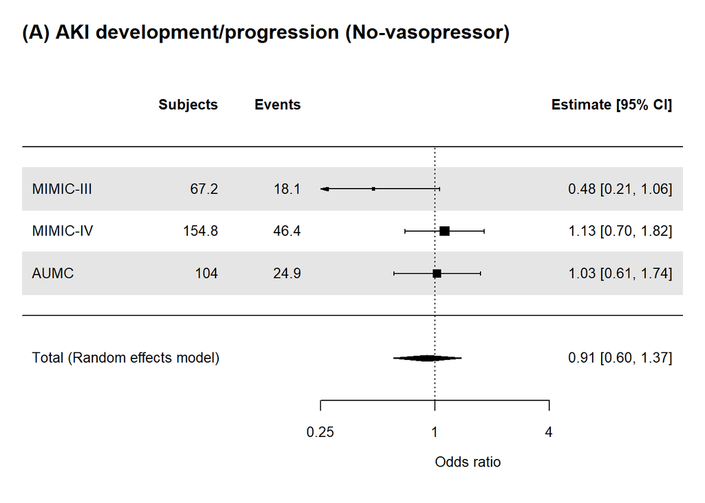

```r
FP2("wgt_man_Ovlp_MIMIC4_nonvaso.rds", FORMULA_ovl2_vaso)
FP2("wgt_man_Ovlp_MIMIC3_nonvaso.rds", FORMULA_ovl2_vaso)
FP2("wgt_man_Ovlp_AUMC_nonvaso.rds", FORMULA_ovl2_vaso)

nonvaso_METADF0 <- rbind(
  readRDS("ORRES_wgt_man_Ovlp_MIMIC3_nonvaso.rds") %>% mutate("dataset"="MIMIC-III"),
  readRDS("ORRES_wgt_man_Ovlp_MIMIC4_nonvaso.rds") %>% mutate("dataset"="MIMIC-IV"),
  readRDS("ORRES_wgt_man_Ovlp_AUMC_nonvaso.rds") %>% mutate("dataset"="AUMC"))
nonvaso_METADF_AKID <- nonvaso_METADF0 %>% subset(outcome=="outcome_KDIGO_inc_or_death")
nonvaso_METADF_AKI <- nonvaso_METADF0 %>% subset(outcome=="outcome_KDIGO_inc")
nonvaso_METADF_HD <- nonvaso_METADF0 %>% subset(outcome=="outcome_new_dial")
nonvaso_METADF_D <- nonvaso_METADF0 %>% subset(outcome=="death_in_7d")
nonvaso_METADF_HDD <- nonvaso_METADF0 %>% subset(outcome=="outcome_HDD_in7d")

nonvaso_METARES_AKID <- rma(yi = Estimate, sei = Std.Error, method = "REML", data = nonvaso_METADF_AKID)
nonvaso_METARES_AKI <-rma(yi = Estimate, sei = Std.Error, method = "REML", data = nonvaso_METADF_AKI)
nonvaso_METARES_HD <- rma(yi = Estimate, sei = Std.Error, method = "REML", data = nonvaso_METADF_HD)
nonvaso_METARES_D <- rma(yi = Estimate, sei = Std.Error, method = "REML", data = nonvaso_METADF_D)
nonvaso_METARES_HDD <- rma(yi = Estimate, sei = Std.Error, method = "REML", data = nonvaso_METADF_HDD)

METAF(nonvaso_METARES_AKI, SCALEA1, SCALEB1, SCALEC1, "(A) AKI development/progression (No-vasopressor)")
```

```r
nonvaso_METARES_AKI
```

```
##
## Random-Effects Model (k = 3; tau^2 estimator: REML)
##
## tau^2 (estimated amount of total heterogeneity): 0.0449 (SE = 0.1329)
## tau (square root of estimated tau^2 value):      0.2119
## I^2 (total heterogeneity / total variability):   33.80%
## H^2 (total variability / sampling variability):  1.51
##
## Test for Heterogeneity:
## Q(df = 2) = 3.4436, p-val = 0.1787
##
## Model Results:
##
## estimate      se     zval    pval    ci.lb   ci.ub
##  -0.0944  0.2093  -0.4511  0.6519  -0.5046  0.3158
##
## ---
## Signif. codes:  0 '***' 0.001 '**' 0.01 '*' 0.05 '.' 0.1 ' ' 1
```

```r
nonvaso_METADF_AKI %>% dplyr::select(dataset, OR, LCI, UCI, 'Pr(>|z|)') %>% remove_rownames()
```

```
##     dataset        OR       LCI      UCI   Pr(>|z|)
## 1 MIMIC-III 0.4764174 0.2146524 1.057400 0.06834028
## 2  MIMIC-IV 1.1254670 0.6962252 1.819348 0.62955617
## 3      AUMC 1.0287808 0.6080233 1.740706 0.91578499
```

__

#### 12. Firth’s regression -> forest plot.

In some subgroup analyses, outcomes only developed one group. Then, we couldn’t estimate odds ratio. Therefore, we estimated the ratio using Firth’s regression

```r
#Firth's method function
library(logistf) #install.packages("logistf")
DF <- readRDS("wgt_man_Ovlp_MIMIC3_base12.rds")
DF$drug_type <- DF$drug_type %>% factor() %>% relevel(, ref = "NCC")
saveRDS(DF,"wgt_man_Ovlp_MIMIC3_base12.rds")
#logistf(formula = as.formula("outcome_KDIGO_inc ~ drug_type"), data  = readRDS("wgt_man_Ovlp_MIMIC3_base12.rds"), weights = ovlp_wgt)

OVLP_OR_F <- function(DF, FORM, OUTCOME, TITLE){
fit <- logistf(formula = as.formula(paste0(OUTCOME," ~ drug_type")), data  = DF, weights = ovlp_wgt)
fit %>% summary() %>% print()
est<-coef(fit)["drug_typeI/C"]
ci<-confint(fit)["drug_typeI/C", ]
summary1 <- data.frame(Estimate = est, Std.Error = (ci[2] - ci[1]) / (2 * 1.96), lwr=ci[1], upr=ci[2],
                       study=TITLE, outcome=OUTCOME)
svy_design <- svydesign(~1, data = DF %>% as.data.frame(), weights = DF$ovlp_wgt)
fmla <- as.formula(paste("~", OUTCOME))
summary1 <- summary1 %>% mutate("pts"= svytable(fmla, svy_design) %>% as.data.frame() %>% .$Freq %>% sum(),
                                "events"=svytable(fmla, svy_design) %>% as.data.frame() %>% filter(.data[[OUTCOME]]==T) %>% .$Freq %>% sum())
summary1
}

FP2_F <- function(RDS, FORM,  OUTCOME, TITLE){
OR_RES_F <- OVLP_OR_F(readRDS(RDS), FORM, OUTCOME, TITLE) %>%
  mutate("events_percentage"=events/sum(.$event), "pts_percentage"=pts/sum(.$pts))
saveRDS(OR_RES_F, paste0("ORRES_F_",RDS))}



### Start with each assessment
## Subgroup with AKI at treatment start -> AKI progression in mimic3
FP2_F("wgt_man_Ovlp_MIMIC3_base12.rds", FORMULA_ovl2, "outcome_KDIGO_inc", "AKI progression")
```

```
## logistf(formula = as.formula(paste0(OUTCOME, " ~ drug_type")),
##     data = DF, weights = ovlp_wgt)
##
## Model fitted by Penalized ML
## Coefficients:
##                   coef  se(coef) lower 0.95 upper 0.95    Chisq           p
## (Intercept)  -1.616995 0.6845256  -3.226056 -0.4258791 7.544901 0.006018012
## drug_typeI/C -1.780426 1.5923232  -6.741020  0.8305482 1.667019 0.196658323
##              method
## (Intercept)       2
## drug_typeI/C      2
##
## Method: 1-Wald, 2-Profile penalized log-likelihood, 3-None
##
## Likelihood ratio test=1.667019 on 1 df, p=0.1966583, n=28.88692
## Wald test = 11.16444 on 1 df, p = 0.0008338028logistf(formula = as.formula(paste0(OUTCOME, " ~ drug_type")),
##     data = DF, weights = ovlp_wgt)
## Model fitted by Penalized ML
## Confidence intervals and p-values by Profile Likelihood
##
## Coefficients:
##  (Intercept) drug_typeI/C
##    -1.616995    -1.780426
##
## Likelihood ratio test=1.667019 on 1 df, p=0.1966583, n=28.88692
```

```r
base12_METADF_F0 <- rbind( #Firth method only used for MIMIC3
  readRDS("ORRES_F_wgt_man_Ovlp_MIMIC3_base12.rds") %>% dplyr::select(Estimate, Std.Error, outcome, pts, events) %>% mutate("dataset"="MIMIC-III"),
  readRDS("ORRES_wgt_man_Ovlp_MIMIC4_base12.rds") %>% dplyr::select(Estimate, Std.Error, outcome, pts, events) %>% mutate("dataset"="MIMIC-IV"),
  readRDS("ORRES_wgt_man_Ovlp_AUMC_base12.rds") %>% dplyr::select(Estimate, Std.Error, outcome, pts, events) %>%mutate("dataset"="AUMC"))

base12_METADF_F_AKI <- base12_METADF_F0 %>% subset(outcome=="outcome_KDIGO_inc")
base12_METARES_F_AKI <- rma(yi = Estimate, sei = Std.Error, method = "REML", data = base12_METADF_F_AKI)

base12_METARES_F_AKI
```

```
##
## Random-Effects Model (k = 3; tau^2 estimator: REML)
##
## tau^2 (estimated amount of total heterogeneity): 0 (SE = 0.1585)
## tau (square root of estimated tau^2 value):      0
## I^2 (total heterogeneity / total variability):   0.00%
## H^2 (total variability / sampling variability):  1.00
##
## Test for Heterogeneity:
## Q(df = 2) = 1.2510, p-val = 0.5350
##
## Model Results:
##
## estimate      se     zval    pval    ci.lb   ci.ub
##  -0.2375  0.2302  -1.0316  0.3023  -0.6887  0.2137
##
## ---
## Signif. codes:  0 '***' 0.001 '**' 0.01 '*' 0.05 '.' 0.1 ' ' 1
```

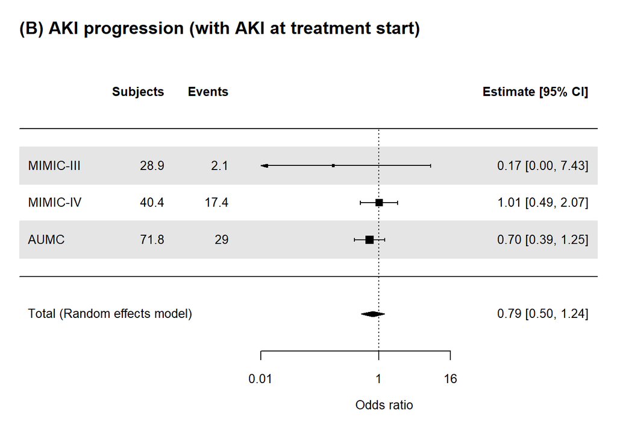

```r
SCALEA4<-c(0.01, 1, 16)
SCALEB4 <- c(-14,8.5)
SCALEC4 <- c(-8,-5.5)
METAF(base12_METARES_F_AKI, SCALEA4, SCALEB4, SCALEC4, "(B) AKI progression (with AKI at treatment start)")
```

```r
## Subgroup without AKI at treatment start -> RRT in mimic4
DFbase <- readRDS("wgt_man_Ovlp_MIMIC4_base0.rds")
DFbase$drug_type <- DFbase$drug_type %>% factor() %>% relevel(, ref = "NCC")
saveRDS(DFbase,"wgt_man_Ovlp_MIMIC4_base0.rds")
FP2_F("wgt_man_Ovlp_MIMIC4_base0.rds", FORMULA_ovl2, "outcome_new_dial", "hemodialysis")
```

```
## logistf(formula = as.formula(paste0(OUTCOME, " ~ drug_type")),
##     data = DF, weights = ovlp_wgt)
##
## Model fitted by Penalized ML
## Coefficients:
##                   coef  se(coef) lower 0.95 upper 0.95    Chisq            p
## (Intercept)  -3.072192 0.6002488  -4.509088  -2.068705 67.39648 2.220446e-16
## drug_typeI/C -1.796876 1.5413175  -6.719030   0.653111  1.92344 1.654780e-01
##              method
## (Intercept)       2
## drug_typeI/C      2
##
## Method: 1-Wald, 2-Profile penalized log-likelihood, 3-None
##
## Likelihood ratio test=1.92344 on 1 df, p=0.165478, n=129.1994
## Wald test = 37.9595 on 1 df, p = 7.222837e-10logistf(formula = as.formula(paste0(OUTCOME, " ~ drug_type")),
##     data = DF, weights = ovlp_wgt)
## Model fitted by Penalized ML
## Confidence intervals and p-values by Profile Likelihood
##
## Coefficients:
##  (Intercept) drug_typeI/C
##    -3.072192    -1.796876
##
## Likelihood ratio test=1.92344 on 1 df, p=0.165478, n=129.1994
```

```r
base0_METADF_F0 <- rbind( #Firth method only used for MIMIC4
  readRDS("ORRES_wgt_man_Ovlp_MIMIC3_base0.rds") %>% dplyr::select(Estimate, Std.Error, outcome, pts, events) %>% mutate("dataset"="MIMIC-III"),
  readRDS("ORRES_F_wgt_man_Ovlp_MIMIC4_base0.rds") %>% dplyr::select(Estimate, Std.Error, outcome, pts, events) %>% mutate("dataset"="MIMIC-IV"),
  readRDS("ORRES_wgt_man_Ovlp_AUMC_base0.rds") %>% dplyr::select(Estimate, Std.Error, outcome, pts, events) %>%mutate("dataset"="AUMC"))

base0_METADF_F_HD <- base0_METADF_F0 %>% subset(outcome=="outcome_new_dial")
base0_METARES_F_HD <- rma(yi = Estimate, sei = Std.Error, method = "REML", data = base0_METADF_F_HD)

base0_METARES_F_HD
```

```
##
## Random-Effects Model (k = 3; tau^2 estimator: REML)
##
## tau^2 (estimated amount of total heterogeneity): 0 (SE = 0.5400)
## tau (square root of estimated tau^2 value):      0
## I^2 (total heterogeneity / total variability):   0.00%
## H^2 (total variability / sampling variability):  1.00
##
## Test for Heterogeneity:
## Q(df = 2) = 1.1400, p-val = 0.5655
##
## Model Results:
##
## estimate      se     zval    pval    ci.lb   ci.ub
##  -0.2087  0.3661  -0.5700  0.5687  -0.9263  0.5089
##
## ---
## Signif. codes:  0 '***' 0.001 '**' 0.01 '*' 0.05 '.' 0.1 ' ' 1
```

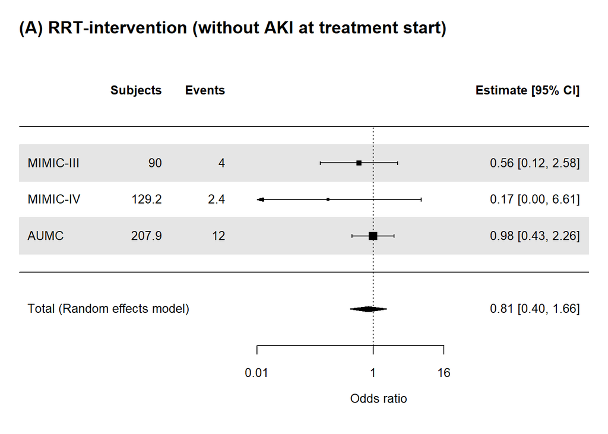

```r
METAF(base0_METARES_F_HD, SCALEA4, SCALEB4, SCALEC4, "(A) RRT-intervention (without AKI at treatment start)")
```

```r
## Subgroup with AKI at treatment start -> RRT in mimic3
DFbase <- readRDS("wgt_man_Ovlp_MIMIC3_base12.rds")
DFbase$drug_type <- DFbase$drug_type %>% factor() %>% relevel(, ref = "NCC")
saveRDS(DFbase,"wgt_man_Ovlp_MIMIC3_base12.rds")
FP2_F("wgt_man_Ovlp_MIMIC3_base12.rds", FORMULA_ovl2, "outcome_new_dial", "hemodialysis")
```

```
## logistf(formula = as.formula(paste0(OUTCOME, " ~ drug_type")),
##     data = DF, weights = ovlp_wgt)
##
## Model fitted by Penalized ML
## Coefficients:
##                   coef se(coef) lower 0.95 upper 0.95      Chisq            p
## (Intercept)  -2.700535 1.047791  -5.653795  -1.085191 14.1511763 0.0001686916
## drug_typeI/C -0.696886 1.778984  -5.784195   2.890707  0.1616515 0.6876405221
##              method
## (Intercept)       2
## drug_typeI/C      2
##
## Method: 1-Wald, 2-Profile penalized log-likelihood, 3-None
##
## Likelihood ratio test=0.1616515 on 1 df, p=0.6876405, n=28.88692
## Wald test = 12.22717 on 1 df, p = 0.0004709869logistf(formula = as.formula(paste0(OUTCOME, " ~ drug_type")),
##     data = DF, weights = ovlp_wgt)
## Model fitted by Penalized ML
## Confidence intervals and p-values by Profile Likelihood
##
## Coefficients:
##  (Intercept) drug_typeI/C
##    -2.700535    -0.696886
##
## Likelihood ratio test=0.1616515 on 1 df, p=0.6876405, n=28.88692
```

```r
base12_METADF_F0 <- rbind( #Firth method only used for MIMIC3
  readRDS("ORRES_F_wgt_man_Ovlp_MIMIC3_base12.rds") %>% dplyr::select(Estimate, Std.Error, outcome, pts, events) %>% mutate("dataset"="MIMIC-III"),
  readRDS("ORRES_wgt_man_Ovlp_MIMIC4_base12.rds") %>% dplyr::select(Estimate, Std.Error, outcome, pts, events) %>% mutate("dataset"="MIMIC-IV"),
  readRDS("ORRES_wgt_man_Ovlp_AUMC_base12.rds") %>% dplyr::select(Estimate, Std.Error, outcome, pts, events) %>%mutate("dataset"="AUMC"))

base12_METADF_F_HD <- base12_METADF_F0 %>% subset(outcome=="outcome_new_dial")
base12_METARES_F_HD <- rma(yi = Estimate, sei = Std.Error, method = "REML", data = base12_METADF_F_HD)

base12_METARES_F_HD
```

```
##
## Random-Effects Model (k = 3; tau^2 estimator: REML)
##
## tau^2 (estimated amount of total heterogeneity): 0 (SE = 0.2672)
## tau (square root of estimated tau^2 value):      0
## I^2 (total heterogeneity / total variability):   0.00%
## H^2 (total variability / sampling variability):  1.00
##
## Test for Heterogeneity:
## Q(df = 2) = 0.3180, p-val = 0.8530
##
## Model Results:
##
## estimate      se     zval    pval    ci.lb   ci.ub
##  -0.2385  0.2896  -0.8236  0.4101  -0.8060  0.3290
##
## ---
## Signif. codes:  0 '***' 0.001 '**' 0.01 '*' 0.05 '.' 0.1 ' ' 1
```

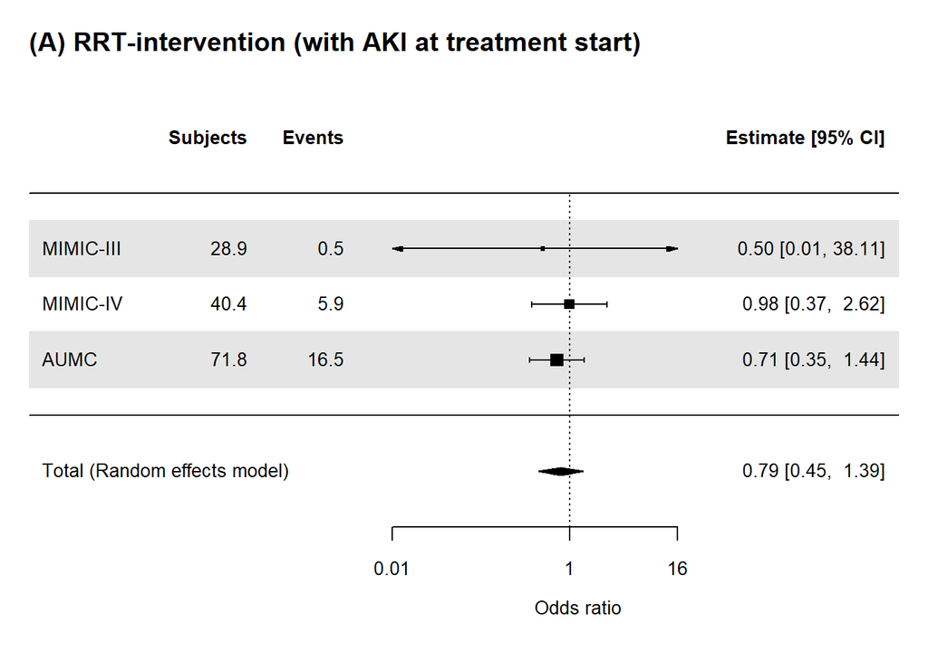

```r
METAF(base12_METARES_F_HD, SCALEA4, SCALEB4, SCALEC4, "(A) RRT-intervention (with AKI at treatment start)")
```

```r
#export
#subgroup main
tiff("Figure 4 (subgroup AKI).tif",
     width = 6,
     height = 8,     # Tall file to fit 3 plots vertically
     units = "in",
     res = 300,
     compression = "lzw")
par(mfrow = c(2, 1))
METAF(base0_METARES_AKI, SCALEA1, SCALEB1, SCALEC1, "(A) AKI development (without AKI at treatment start)")
METAF(base12_METARES_F_AKI, SCALEA4, SCALEB4, SCALEC4, "(B) AKI progression (with AKI at treatment start)")
dev.off()
```

```r
#export wo AKI
tiff("eFigure 4 (secondary wo AKI).tif",
     width = 6,
     height = 8,
     units = "in",
     res = 300,
     compression = "lzw")
par(mfrow = c(3, 1))
METAF(base0_METARES_F_HD, SCALEA4, SCALEB4, SCALEC4, "(A) RRT-intervention (without AKI at treatment start)")
METAF(base0_METARES_D, SCALEA1, SCALEB1, SCALEC1, "(B) Death (without AKI at treatment start)")
METAF(base0_METARES_HDD, SCALEA1, SCALEB1, SCALEC1, "(C) RRT-intervention or death (without AKI at treatment start)")
dev.off()
```

```r
#export w AKI
tiff("eFigure 5 (secondary w AKI).tif",
     width = 6,
     height = 8,
     units = "in",
     res = 300,
     compression = "lzw")
par(mfrow = c(3, 1))
METAF(base12_METARES_F_HD, SCALEA4, SCALEB4, SCALEC4, "(A) RRT-intervention (with AKI at treatment start)")
METAF(base12_METARES_D, SCALEA1, SCALEB1, SCALEC1, "(B) Death (with AKI at treatment start)")
METAF(base12_METARES_HDD, SCALEA1, SCALEB1, SCALEC1, "(C) RRT-intervention or death (with AKI at treatment start)")
dev.off()
```

__

#### 13. Summary of subgroup analysis

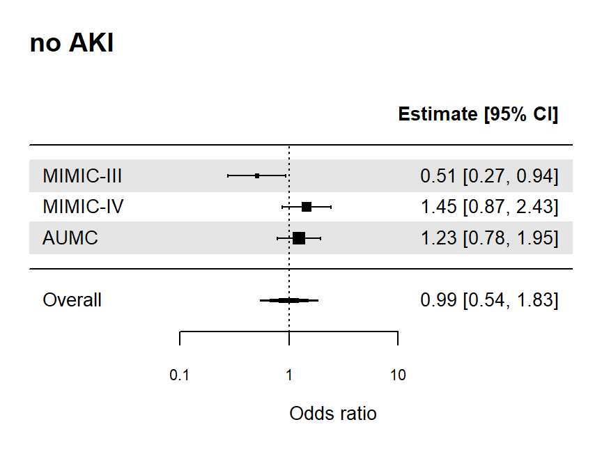

```r
SCALEAsub<-c(0.25, 1, 4)
SCALEBsub <- c(-2.8,3.5)

SCALEAsub2<-c(0.1, 1, 10)
SCALEBsub2 <- c(-5.5, 6)

METAF2 <- function(METARES, AAA, BBB,TITLE){
metafor::forest(METARES,  atransf=exp, at=log(AAA), slab = dataset,
       xlim=BBB,
       #ilab=cbind(round(pts, digits=1), round(events, digits=1)),
       #ilab.lab=c("Subjects","Events"), ilab.pos = 2,
       #ilab.xpos=CCC,
       cex=0.85, cex.axis=0.7, annotate=T,
       header="", xlab="Odds ratio", mlab="Overall", shade=TRUE,
       main=TITLE, adj=0)
}
METAF2(base0_METARES_AKI, SCALEAsub2, SCALEBsub2,  "no AKI")
```

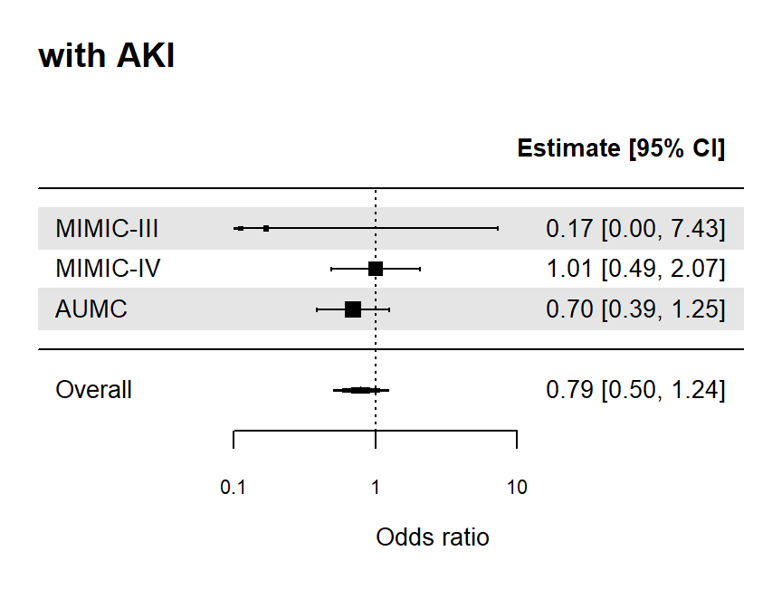

```r
METAF2(base12_METARES_F_AKI, SCALEAsub2, SCALEBsub2, "with AKI") #Filth!!!
```

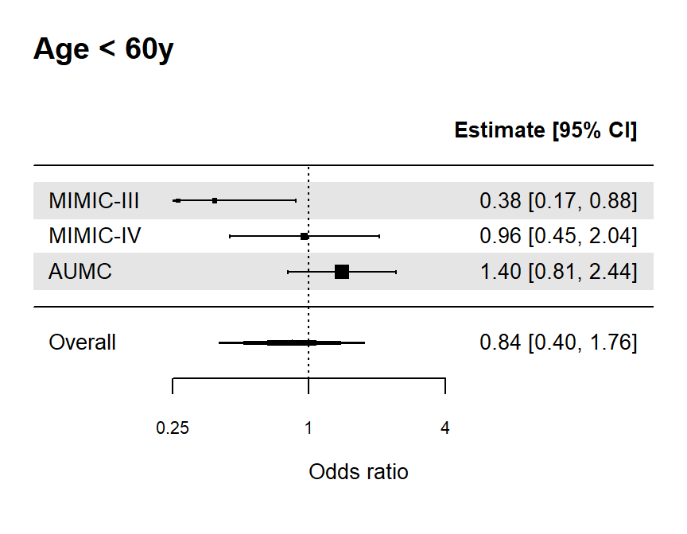

```r
METAF2(Young_METARES_AKI, SCALEAsub, SCALEBsub, "Age < 60y")
```

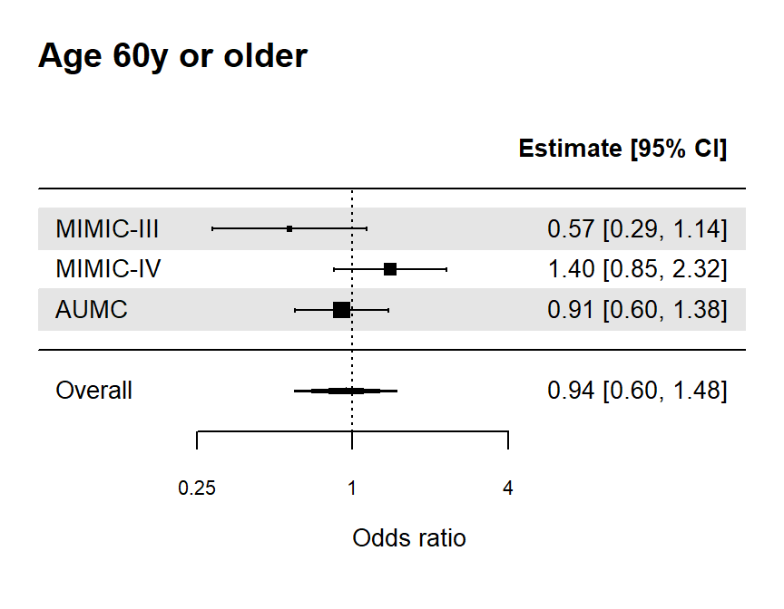

```r
METAF2(Old_METARES_AKI, SCALEAsub, SCALEBsub, "Age 60y or older")
```

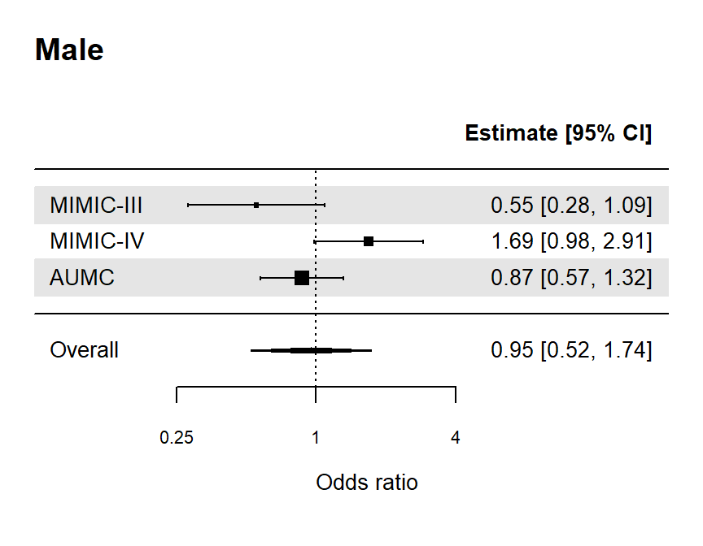

```r
METAF2(Male_METARES_AKI, SCALEAsub, SCALEBsub, "Male")
```

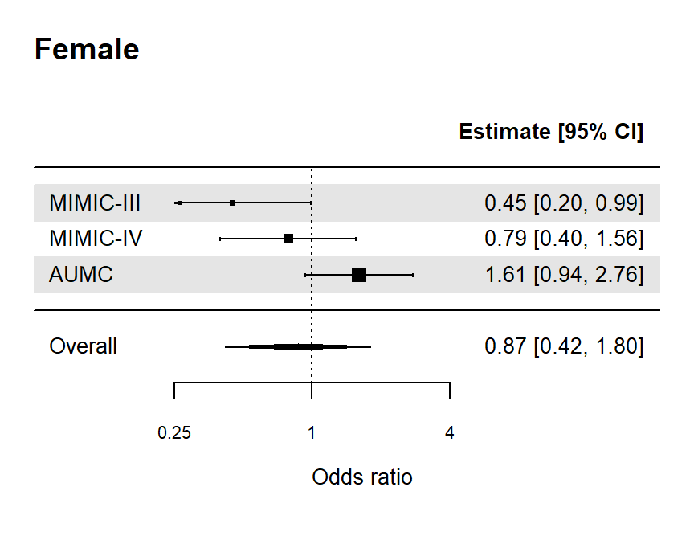

```r
METAF2(Female_METARES_AKI, SCALEAsub, SCALEBsub, "Female")
```

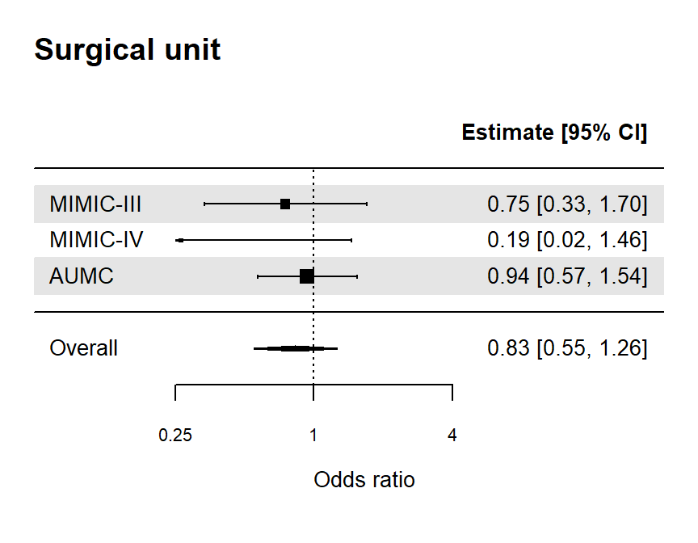

```r
METAF2(surg_METARES_AKI, SCALEAsub, SCALEBsub, "Surgical unit")
```

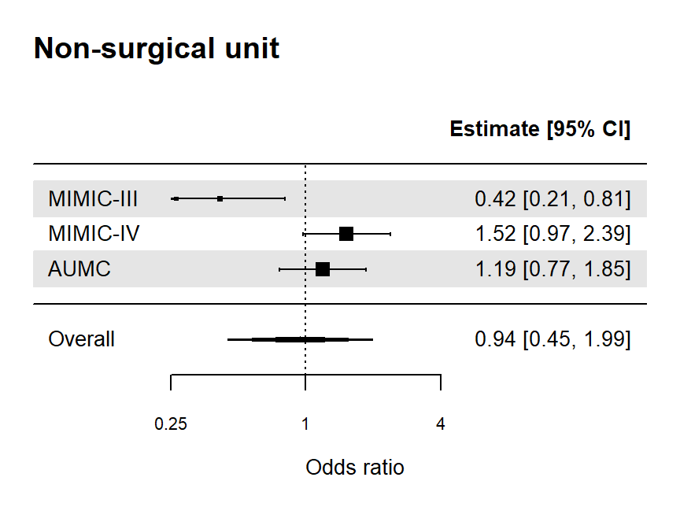

```r
METAF2(nonsurg_METARES_AKI, SCALEAsub, SCALEBsub, "Non-surgical unit")
```

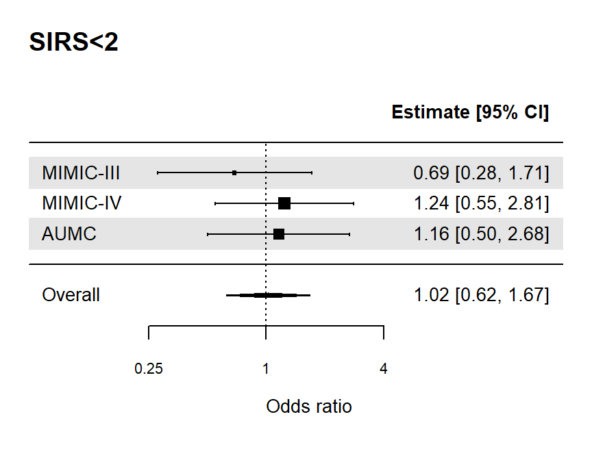

```r
METAF2(Lsirs_METARES_AKI, SCALEAsub, SCALEBsub, "SIRS<2")
```

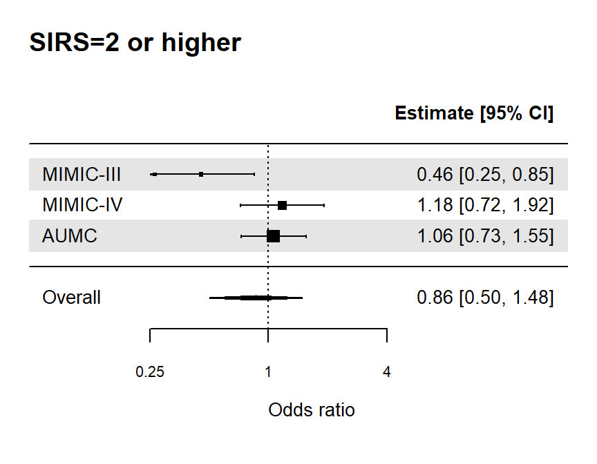

```r
METAF2(Hsirs_METARES_AKI, SCALEAsub, SCALEBsub, "SIRS=2 or higher")
```

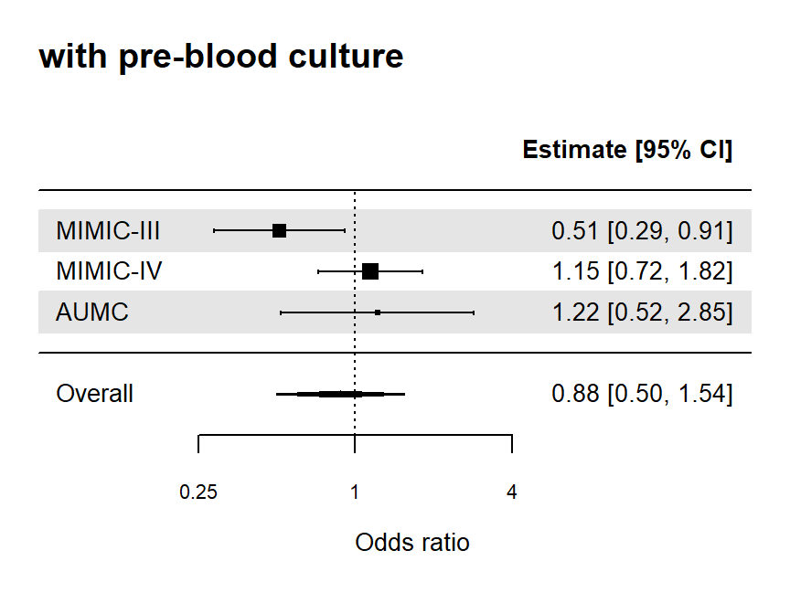

```r
METAF2(bc_METARES_AKI, SCALEAsub, SCALEBsub, "with pre-blood culture")
```

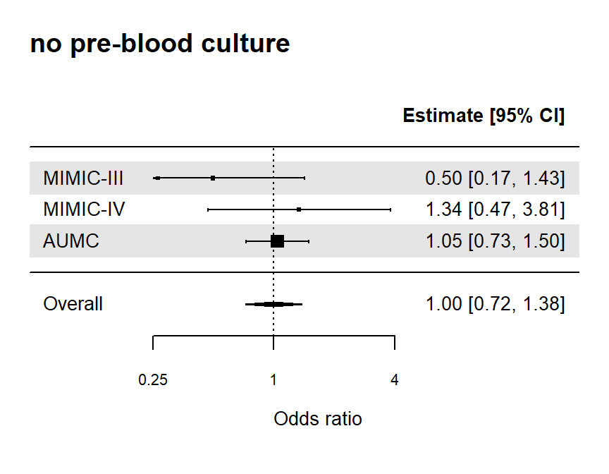

```r
METAF2(nonbc_METARES_AKI, SCALEAsub, SCALEBsub, "no pre-blood culture")
```

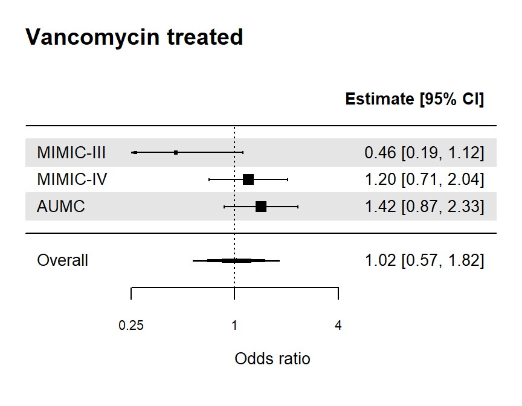

```r
METAF2(vc_METARES_AKI, SCALEAsub, SCALEBsub, "Vancomycin treated")
```

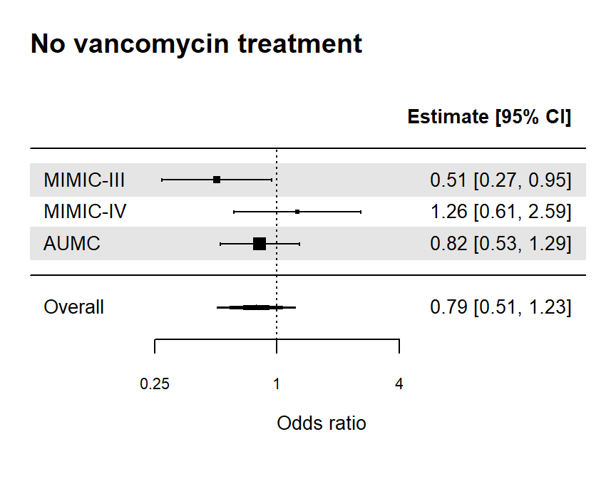

```r
METAF2(novc_METARES_AKI, SCALEAsub, SCALEBsub, "No vancomycin treatment")
```

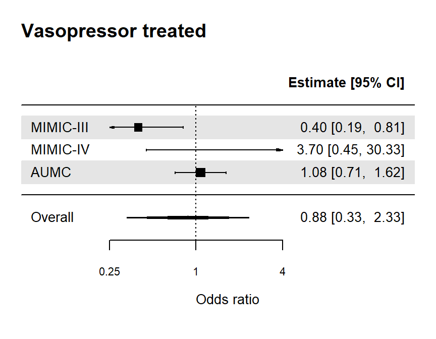

```r
METAF2(vaso_METARES_AKI, SCALEAsub, SCALEBsub, "Vasopressor treated")
```

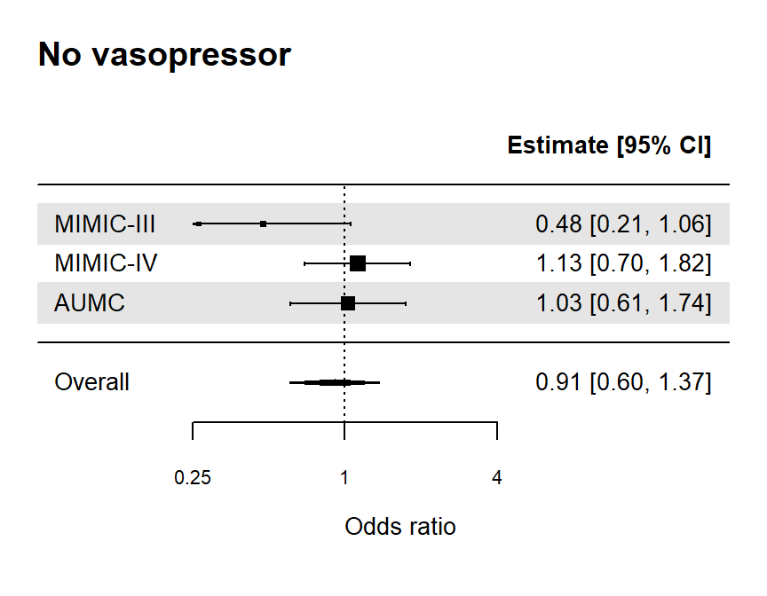

```r
METAF2(nonvaso_METARES_AKI, SCALEAsub, SCALEBsub, "No vasopressor")
```

```r
#export
tiff("eFigure 6 (various subgroup).tif",
     width = 16,
     height = 16,     # Tall file to fit 3 plots vertically
     units = "in",
     res = 300,
     compression = "lzw")
par(mfrow = c(4, 4))
METAF2(Young_METARES_AKI, SCALEAsub, SCALEBsub, "Age < 60y")
METAF2(Old_METARES_AKI, SCALEAsub, SCALEBsub, "Age 60y or older")
METAF2(Male_METARES_AKI, SCALEAsub, SCALEBsub, "Male")
METAF2(Female_METARES_AKI, SCALEAsub, SCALEBsub, "Female")
METAF2(surg_METARES_AKI, SCALEAsub, SCALEBsub, "Surgical unit")
METAF2(nonsurg_METARES_AKI, SCALEAsub, SCALEBsub, "Non-surgical unit")
METAF2(Lsirs_METARES_AKI, SCALEAsub, SCALEBsub, "SIRS<2")
METAF2(Hsirs_METARES_AKI, SCALEAsub, SCALEBsub, "SIRS=2 or higher")
METAF2(bc_METARES_AKI, SCALEAsub, SCALEBsub, "with pre-blood culture")
METAF2(nonbc_METARES_AKI, SCALEAsub, SCALEBsub, "no pre-blood culture")
METAF2(vc_METARES_AKI, SCALEAsub, SCALEBsub, "Vancomycin treated")
METAF2(novc_METARES_AKI, SCALEAsub, SCALEBsub, "No vancomycin treatment")
METAF2(vaso_METARES_AKI, SCALEAsub, SCALEBsub, "Vasopressor treated")
METAF2(nonvaso_METARES_AKI, SCALEAsub, SCALEBsub, "No vasopressor")
dev.off()
```